# MINI-PROJET GROUPE 5 - OPTIMISATION Trajectoire optimale de course d'un véhicule électrique

**Emma Bou Hanna, Sandra Clodion**

## I/ Modélisation

### Question 1

Justifier que, sous des hypothèses raisonnables, on peut réduire le problème au suivant : minimiser l'énergie dépensée pendant un tour de piste (on précisera les contraintes associées à ce nouveau problème)

**Réponse :**

- Hypothèses:
  - On suppose que la voiture roule sans glisser sur le sol (bitume sans défaut)
  - Les frottements fluides sont quadratiques au vu des valeurs usuelles de vitesse d'une voiture
  - La vitesse est bornée inférieurement et supérieurement
  - On suppose que la puissance électrique initiale est telle qu'on peut effectuer un grand nombre de tour
- Simplification du problème:

On considère uniquement l'optimisation du profil de vitesse lors d'un tour car lorsque l'on effectue un bilan de puissance, on se rend compte que ce sont les mêmes forces qui interviennent à chaque tour et les mêmes grandeurs qui sont en jeu. Le problème est donc fortement similaire à chaque tour. Ainsi, les conditions sur la vitesse que nous trouverons dans le cadre d'une résolution du problème sur un tour s'appliqueront pour les autres tours de la même façon.

- Contraintes associées à ce nouveau problème :
  - vérification à tout instant de l'équation du mouvement
  - vitesse de la voiture bornée entre $v_{min}$ et $v_{max}$

### Question 2

En introduisant l'abscisse curviligne d'une courbe et en exploitant le modèle de moteur donné en annexe, écrire la fonction objectif à minimiser

**Réponse:**

- On suppose que le circuit est donné sous forme d'arc paramétré, donné par la fonction : $\overrightarrow {OM} =\overrightarrow {g(t)}$, pour $t$ dans l'intervalle $[t_0, t_f]$ où $t_0$ est l'instant où le véhicule commence son tour et $t_f$ celui auquel il le termine.

  On fait l'hypothèse que cet arc paramétré est de classe $\mathcal{C^{1}}$, ce qui est une hypothèse raisonnable étant donné les allures des circuits automobiles.

  On introduit l'abscisse curviligne d'origine $t_{0}$ comme étant $s(t)=\int _{{t_{0}}}^{t}\left\|{\frac {{\mathrm d}\overrightarrow {g}(\tau )}{{\mathrm d}\tau }}\right\|{\mathrm d}\tau = \int _{{t_{0}}}^{t}\left\|\overrightarrow {v(\tau)}\right\|{\mathrm d}\tau$
- On note $ T(t) = \tau u(t)$ $\,(1)$ , où $\tau$ est le couple moteur maximal et $u(t)\in [0,1]$  
  Le modèle de moteur donné en annexe nous donne les équations suivantes :

$$T(t) = \kappa I_{m}(t) \qquad (2)$$$$R_{m}I_{m}(t) = U_{m}(t) - \kappa \omega(t) \qquad (3)$$

En multipliant chaque membre de l'équation (3) par $I_{m}(t)$, on obtient l'équation suivante : $$ R_{m}I_{m}(t)^{2} = U_{m}(t)I_{m}(t) - \kappa I_{m}(t) \omega(t)$$

On remarque que la puissance électrique fournie par le moteur est en partie perdue par effet Joule ($R_{m}I_{m}(t)^{2}$) et en partie convertie en puissance mécanique ($\kappa I_{m}(t) \omega(t)$).

On peut alors réécrire l'équation précédente uniquement en fonction de $u$ et de $w$: $$ \boxed{\mathcal{P}_{e}(t) = \frac{R_{m}}{\kappa ^{2}}(\tau u(t))^{2} + \tau u(t) \omega(t)} \quad (4) $$ où $ \mathcal{P}_{e}(t) = U_{m}(t)I_{m}(t)$ est la puissance d'entrée du moteur

- On veut minimiser l'énergie perdue par le véhicule pendant un tour, c'est-à-dire qu'on veut minimiser $ -\Delta E_{c} $ D'après le théorème de l'énergie cinétique appliqué dans le référentiel lié au sol, $ \Delta E_{c} = \int_{t_{0}}^{t_f} (\mathcal{P}(\overrightarrow{actions \, extérieures}) + \mathcal{P}(\overrightarrow{actions \, intérieures})) \: dt$

  On se place dans le repère mobile d'origine $M(t)$ (la position du véhicule à l'instant $t$) porté par les vecteurs orthonomés $(\overrightarrow{T}, \overrightarrow{N}, \overrightarrow{A})$, où $\overrightarrow{T}$ et $\overrightarrow{N}$ sont respectivement les vecteurs tangentiel unitaire et normal du repère de Frénet lié au véhicule. On considère également le troisième vecteur unitaire du repère cartésien $\overrightarrow{e_z}$, utile par la suite pour projeter le poids sur les vecteurs de la base de Frénet.

  On note $\theta(t)$ l'angle algébrique de pente du circuit à l'abscisse où se trouve le véhicule à l'instant $t$. C'est l'angle entre l'horizontale et la direction de la tangente au circuit (qui est aussi la direction de $\overrightarrow{v}$)

  Le véhicule est modélisé par un point $M(t)$
- Bilan des forces :
  - le poids $\overrightarrow{P}$ = $ - mg (\sin{\theta(t)} \overrightarrow{T} + \cos{\theta(t)}\overrightarrow{N}$)
  - la réaction de contact sur chacune des roues, qu'on peut décomposer comme la somme d'une réaction normale à la route et d'une réaction tangentielle $\overrightarrow{R_{Ci}(t)} = R_{Ni}(t) \overrightarrow{N} + R_{Ti}(t) \overrightarrow{T}$ (pour chacune des roues $i$)
  - la force de frottement fluide due à l'air $\overrightarrow{F_{air}}=-\alpha \left\|v(t)\right\|\overrightarrow{v(t)} $
  - Dans la suite, on identifie $v(t) = \left\|v(t)\right\|$
- Ici, parmi les actions extérieures au système :
  - la puissance de la réaction du sol est nulle d'après l'hypothèse de non-glissement de la roue (cf question 3)
  - la puissance du poids à l'instant $t$ vaut $ - mg\sin{\theta(t)}v(t) $
  - la puissance de la force de frottement due à l'air à l'instant $t$ vaut $ - \alpha v(t)^{3} dt $
- La fonction de côut du problème d'optimisation qu'on cherche à résoudre est donc la suivante : $$f(v(t), u(t), w(t)) = \int_{t_{0}}^{t_{f}} (\alpha v(t)^{3} + mg\sin{\theta(t)}v(t) - \mathcal{P}_{e}(t) ) \: dt$$ que l'on peut réécrire de la façon suivante : $$\boxed{f(v(t), u(t), w(t)) = \int_{t_{0}}^{t_{f}} (\alpha v(t)^{3} + mg\sin{\theta(t)}v(t) - \frac{R_{m}}{\kappa ^{2}}(\tau u(t))^{2} - \tau u(t) \omega(t)) \: dt}$$ où :
  - les variables de décision sont pour l'instant les fonctions $\boxed{v: [t_{0}, t_{f}] \rightarrow \mathbb{R}}$, $\boxed{w: [t_{0}, t_{f}] \rightarrow \mathbb{R}}$ et $\boxed{u: [t_{0}, t_{f}] \rightarrow [0,1]}$
  - $L$ est la longueur totale de la piste
  - $t_{0}$ est l'instant où le véhicule démarre son tour de piste
  - $t_{f}$ est l'instant où le véhicule a fait le tour de la piste (il est revenu à son point de départ)
  - la fonction $\theta: [t_{0}, t_{f}] \rightarrow \mathbb{R}$ est supposée connue, car c'est une caractéristique du circuit.

Par la suite, on va essayer de trouver des relations reliant $v(t)$, $w(t)$ et $u(t)$ pour se ramener à une seule variable de décision dans le problème continu. Ce dernier sera ainsi piloté par $u$.

### Question 3

Sous des hypothèses raisonnables, proposer une relation simple liant vitesse de rotation du rotor du moteur et vitesse du véhicule

**Réponse:**

L'exécution de la cellule ci-dessous permet l'affichage d'un schéma utilisé pour cette question

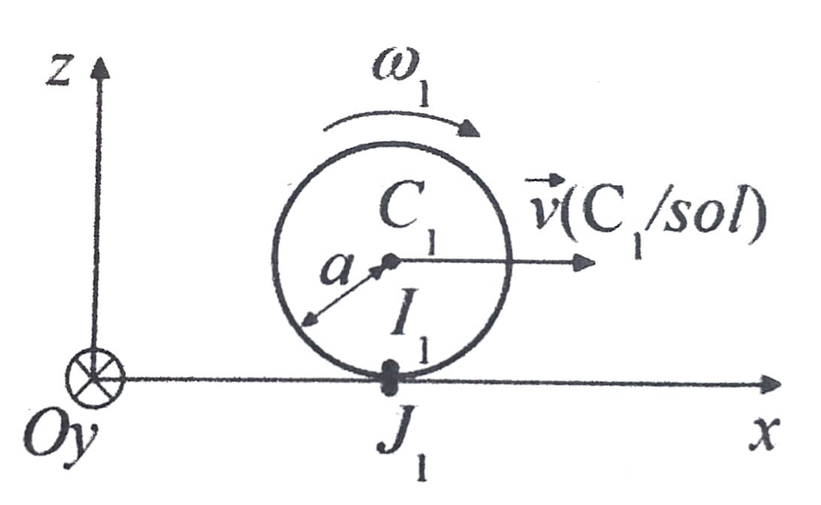

```python
from IPython.display import Image
Image(filename = "schema.jpeg", width=400)
```

- On fait l'hypothèse que **les roues roulent sans glisser sur le sol** et que **les quatre roues ont un comportement identique**. Sur le schéma ci-dessus, $I_{1}$ est un point fixe situé à la périphérie de la roue et $J_{1}$ un point fixe situé sur le sol. Ces deux points sont en contact à l'instant $t$ considéré sur le schéma. On dit qu'il y a non-glissement de la roue sur le sol sur le sol si les vitesses des deux points en contact $I_{1}$ et $J_{1}$ à l'instant $t$ sont égales.  
  On a donc ici : $\overrightarrow{v}(I_{1}/sol) = \overrightarrow{v}(J_{1}/sol)$  
  En notant :
  - **$\overrightarrow{\omega_{1}}(t)$ le vecteur vitesse angulaire de rotation de la roue**
  - **$a$ le rayon de la roue**

    on a aussi :
  - d'une part, $\overrightarrow{v}(I_{1}/sol) = \overrightarrow{v}(C_{1}/sol)+\overrightarrow{\omega_{1}}(t)\wedge\overrightarrow{C_{1}I_{1}}$
  - d'autre part, $\overrightarrow{v}(J_{1}/sol)$ car $J_{1}$ est un point fixe du sol

    Comme $\overrightarrow{v}(C_{1}/sol)$ peut aussi être notée $\overrightarrow{v}$ la vitesse du véhicule, on a finalement : $$ v(t) = a \omega_{1}(t) $$
- On fait l'hypothèse que la vitesse de rotation d'une roue est directement proportionnelle à la vitesse de rotation du rotor.  
  On note **$r$ le rapport de transmission du moteur**, c'est-à-dire $ r = \frac{\omega_{1}(t)}{\omega(t)} $  
  Dans le cas d'un moteur de voiture, on a $r < 1$
- Ainsi, on obtient une relation simple entre la vitesse de rotation du rotor et la vitesse de déplacement du véhicule :

$$ \boxed{v(t) = a r \omega(t)} $$

Cette relation entre $w(t)$ et $v(t)$ nous permet de simplifier l'écriture de la fonction f :

$$f(v(t), u(t)) = \int_{t_{0}}^{t_{f}} (\alpha v(t)^{3} + mg\sin{\theta(t)}v(t) - \frac{R_{m}}{\kappa ^{2}}(\tau u(t))^{2} - \tau u(t) \frac{1}{ar}v(t)) \: dt$$

### Question 4

Effectuer un bilan des forces agissant sur le véhicule et en déduire l'équation dynamique régissant son mouvement

**Réponse:**

- Système : ensemble de la voiture
- Référentiel : lié au sol, supposé galiléen
- Bilan des forces :
  - le poids $\overrightarrow{P}$ = $ - mg (\sin{\theta(t)} \overrightarrow{T} + \cos{\theta(t)}\overrightarrow{N}$)
  - la réaction de contact sur chacune des roues, qu'on peut décomposer comme la somme d'une réaction normale à la route et d'une réaction tangentielle $\overrightarrow{R_{Ci}(t)} = R_{Ni}(t) \overrightarrow{N} + R_{Ti}(t) \overrightarrow{T}$ (pour chacune des roues $i$)
  - la force de frottement fluide due à l'air $\overrightarrow{F_{air}}=-\alpha \left\|v(t)\right\|\overrightarrow{v(t)} $

$\overrightarrow{F_{air}}$ et les $\overrightarrow{R_{Ti}(t)}$ sont colinéaires à $\overrightarrow{v(t)}$

On note $\overrightarrow{R_{T}} = R_{T} \overrightarrow{T} $ la résultante des réactions tangentielles

En appliquant le principe fondamental de la dynamique et en le projetant sur le vecteur $\overrightarrow{T}$ , on obtient :

$$ \boxed{m \frac{dv}{dt} = - \alpha v(t)^{2} + R_{T}(t) - mg\sin{\theta(t)}} \quad (5)$$

où $v(t)$ désigne $\left\|\overrightarrow{v(t)}\right\|$

En multipliant chaque membre de l'équation $(5)$ par $v$, on obtient : $$ \frac{dE_{c}}{dt} = - \alpha v(t)^{3} + R_{T}(t)v(t) - mg\sin{\theta(t)}v(t)$$

En utilisant le théorème de la puissance cinétique et en identifiant, on trouve : $ R_{T}(t)v(t) = \mathcal{P}_{e}(t) $

En substituant dans l'équation $(4)$, on obtient : $$ R_{T}(t) = \frac{R_{m}}{\kappa ^{2}v(t)}T(t)^{2} + \frac{\omega(t)}{v(t)}T(t) $$

On utilise la relation reliant la vitesse de rotation du rotor à la vitesse du véhicule trouvée à la question 3 : $$ R_{T}(t) = \frac{R_{m}}{\kappa ^{2}v(t)}T(t)^{2} + \frac{1}{a r}T(t) $$

Enfin, dans l'équation $(5)$, on remplace $R_{T}$ par son expression qu'on vient de trouver, ce qui nous donne l'équation de mouvement du véhicule : $$ m \frac{dv}{dt} = - \alpha v(t)^{2} - mg\sin{\theta(t)} + \frac{R_{m}}{\kappa ^{2}v(t)}T(t)^{2} + \frac{1}{a r}T(t) $$ qu'on peut réécrire en fonction de $u(t)$ :

$$ \boxed{ m \frac{dv}{dt} = - \alpha v(t)^{2} - mg\sin{\theta(t)} + \frac{R_{m}}{\kappa ^{2}v(t)}(\tau u(t))^{2} + \frac{1}{a r}\tau u(t)}\quad (6) $$

On a ainsi établi une relation entre $v(t)$ et $u(t)$ qui étaient nos deux variables de décisions restantes. Maintenant, on choisit d'exprimer toutes nos variables de décision ($v$, $w$, $u$) uniquement en fonction de $u$, car c'est celle qui a le plus de sens physiquement. En effet, il est plus facile de jouer sur $u$ pour optimiser le profil de vitesse de la voiture, que de jouer sur $w$ ou sur $v$ car on a plus de contrôle sur $u$.

### Question 5

On introduit $n$ points de passage équidistants sur le plan de course et on s'intéresse aux temps de passage par ces points. Discrétiser le problème pour le mettre sous la forme $$\underset{x \in \mathbb{R}^{2n}\\ c(x) \leq 0}{\min \: f(x)}$$ On précisera les variables de décision, les contraintes (au nombre de trois) ainsi que la fonction objectif $f$ à minimiser

**Réponse:**

On note $(t_{1}, ..., t_{n}, t_{n+1})$ les temps d'arrivée respectifs aux $n$ points de passages, avec $t_1$ le point tel que $s(t_1) = 0$, et $t_{n+1}$ le point tel que $s(t_{n+1}) = L$ (le véhicule a fait un tour complet), où $s(t)$ correspond à l'abscisse curviligne de la voiture à l'instant $t$ (Si on considère plusieurs tours, le $t_1$ d'un tour correspond au $t_{n+1}$ du tour précédent)  
On note $(u_{1}, ..., u_{n})$ les pilotages du couple moteur correspondant à chacun des instants $(t_{1}, ..., t_{n})$  
On note $(\theta_{1}, ..., \theta_{n})$ les valeurs des angles de pente du circuit à chacun des points de passage $(1, ..., n)$. On suppose ces valeurs connues ou directement déductibles des équations décrivant le circuit.

On va discrétiser la fonction $f$. Pour cela, on commence par trouver une expression de $f$ en fonction des $u(t_{i})$ et des $v(t_{i})$

- On a d'une part : $$f(v(t),u(t)) = \sum_{i=1}^{n} (\int_{t_{i}}^{t_{i+1}} (\alpha v(t)^{3} + mg\sin{\theta(t)}v(t) - \mathcal{P}_{e}(t)) \: dt)$$ À l'aide d'un développement limité, on en déduit une expression approchée de $f$ à l'ordre 1 : $$ f(v(t),u(t)) = \sum_{i=1}^{n} (\alpha v(t_{i})^{3} + mg\sin{\theta_i}v(t_i) - \mathcal{P}_{e}(t_{i}) ) \times (t_{i+1} - t_{i})$$
- D'autre part, discrétisons l'équation $(6)$ évaluée en $t_i$ pour $i \in [\![1,n]\!]$ :

  Au premier ordre, par méthode des différences finies, on a : $\frac{dv}{dt} (t_i) = \frac{v(t_{i+1}) - v(t_{i})}{t_{i+1} - t_{i}}$ On obtient ainsi une relation de récurrence au premier ordre de la vitesse, exprimée en fonction de $u$:

$$ v(t_{i+1}) = v(t_{i}) + [- mg\sin{\theta_i} + \frac{1}{ra} \tau u(t_{i}) - \alpha v(t_{i})^2 + \frac {R_m}{\kappa^2 v(t_{i})} \tau^2 u(t_{i})^2] \times \frac{(t_{i+1} - t_{i})}{m}$$

- Enfin, on reprend la relation $(4)$ et on en déduit :

$$ \mathcal{P}_{e}(t_i) = \frac{R_{m}}{\kappa ^{2}}(\tau u(t_i))^{2} + \tau u(t_i) \times \frac{v(t_i)}{ra} \quad $$

- On peut ainsi modifier l'expression approchée de f à l'ordre 1 :

$$f(v(t),u(t)) = \sum_{i=1}^{n}(\alpha v(t_{i})^{3} + mg\sin{\theta_i}v(t_{i}) - \frac{R_{m}}{\kappa^{2}}(\tau u(t_{i}))^{2} - \tau u(t_{i}) \frac{v(t_{i})}{ra} ) \times (t_{i+1} - t_{i})$$

On va maintenant essayer d'exprimer les $v(t_i)$ en fonction des $u_i$ et des $t_i$

- On choisit des points **équidistants**, on doit donc avoir : $$ \forall i \in [\![1,n+1]\!], \quad s(t_{i}) = (i-1) \times \frac{L}{n}$$ Cela peut se reformuler de la manière suivante : $$ \forall i \in [\![1,n]\!], \quad s(t_{i+1}) - s(t_{i})= \frac{L}{n}$$
- Par différence finie, on peut donner une approximation au premier ordre de $v(t_i)$ à partir de $t_i$, $t_{i+1}$, et les positions à ces temps de passage :

  $$v(t_i)=\frac{s(t_{i+1})-s(t_i)}{t_{i+1}-t_i}$$

  En utilisant le fait que les points de passages sont équidistants, on en déduit :

$$ v(t_i)=\frac{L}{n(t_{i+1}-t_i)}$$

On introduit les variables $\Delta t_{i}$ telles que :

$${\Delta t_{i}= t_{i + 1} - t_{i} \quad \forall i \in [\![1,n]\!]}$$

Ainsi, on peut réécrire les $v(t_i)$:

$$v(t_i) = \frac{L}{n\Delta t_{i}}$$

On peut ainsi donner une version discrétisée de la fonction f, en écrivant :

$$f(x) = \sum_{i=1}^{n}(\alpha (\frac{L}{n\Delta t_{i}})^{3} + mg\sin{\theta_i}\frac{L}{n\Delta t_{i}} - \frac{R_{m}}{\kappa^{2}}(\tau u_{i})^{2} - \tau u_{i} \frac{L}{nra\Delta t_{i}})\Delta t_{i} $$

qu'on peut simplifier : $$\boxed{f(x) = \sum_{i=1}^{n}\alpha (\frac{L^{3}}{n^{3}\Delta t_{i}^{2}}) + mg\sin{\theta_i}\frac{L}{n} - \frac{R_{m}}{\kappa^{2}}(\tau u_{i})^{2} - \tau u_{i} \frac{L}{nra}} $$ où $ x = \begin{pmatrix}\Delta t_{1} \\ \vdots \\ \Delta t_{n} \\u_1 \\ \vdots \\u_n\end{pmatrix}$, ce qui nous permet d'avoir pour notre problème de minimisation d'avoir un vecteur et non plus des fonctions comme variable de décision de notre problème de minimisation

Les contraintes du problème d'optimisation peuvent également être réécrites en fonction des $u_i$ et des $s_i$

- La contrainte $v_{min}\leq v(t_i) \leq v_{max} \; \forall i \in [\![1,n]\!]$ peut être réécrite : $$v_{min}\leq \frac{L}{n\Delta t_{i}} \leq v_{max} \; \forall i \in [\![1,n]\!]$$ ou encore $$\frac{L}{nv_{max}} \leq \Delta t_{i} \leq \frac{L}{nv_{min}} \; \forall i \in [\![1,n]\!]$$
- La contrainte $0 \leq u(t_i) \leq 1 \; \forall i \in [\![1,n]\!]$ peut être réécrite : $$0 \leq u_i\leq 1 \; \forall i \in [\![1,n]\!]$$
- La contrainte liée à l'équation du mouvement $ v(t_{i+1}) = v(t_{i}) + [- mg\sin{\theta_i} + \frac{1}{ra} \tau u(t_{i}) - \alpha v(t_{i})^2 + \frac {R_m}{\kappa^2 v(t_{i})} \tau^2 u(t_{i})^2] \times \frac{(t_{i+1} - t_{i})}{m}$ peut s'écrire:

$$ \frac{L}{n\Delta t_{i+1}} = \frac{L}{n\Delta t_{i}} + [- mg\sin{\theta_i} + \frac{1}{ra} \tau u_{i} - \alpha (\frac{L}{n\Delta t_{i}})^2 + \frac {nR_m\Delta t_{i}}{\kappa^2 L} \tau^2 u_{i}^2] \times \frac{\Delta t_{i}}{m} \quad \forall i \in [\![1,n-1]\!]$$

ou encore: $$\frac{1}{\Delta t_{i+1}} = (1-\frac{\alpha L}{mn}) \times \frac{1}{\Delta t_{i}} + (\frac{n \tau}{L m R a} u_i - \frac{ng \sin{\theta_i}}{L}) \Delta t_{i} + \frac{n^{2} \tau^{2} R_m}{L^{2} \kappa^{2} m} u_i^{2} \Delta t_{i}^{2}\quad \forall i \in [\![1,n-1]\!]$$

Le problème d'optimisation s'écrit donc : $$\underset{ x \in \mathbb{R}^{2n} \\ \frac{1}{\Delta t_{i+1}} = (1-\frac{\alpha L}{mn}) \times \frac{1}{\Delta t_{i}} + (\frac{n \tau}{L m R a} u_i - \frac{ng \sin{\theta_i}}{L}) \Delta t_{i} + \frac{n^{2} \tau^{2} R_m}{L^{2} \kappa^{2} m} u_i^{2} \Delta t_{i}^{2}\quad \forall i \in [\![1,n-1]\!] \\ v_{min}\leq \frac{L}{n\Delta t_i} \leq v_{max} \; \forall i \in [\![1,n]\!] \\ 0\leq u_i\leq 1 \; \forall i \in [\![1,n]\!] } {\min \: f(x)}$$

où $f(x) = \sum_{i=1}^{n}\alpha (\frac{L^{3}}{n^{3}\Delta t_{i}^{2}}) + mg\sin{\theta_i}\frac{L}{n} - \frac{R_{m}}{\kappa^{2}}(\tau u_{i})^{2} - \tau u_{i} \frac{L}{nra}$

On peut le réécrire, plus formellement, de la façon suivante :

$$ \boxed{\underset{ x \in \mathbb{R}^{2n} \\ \frac{1}{\Delta t_{i+1}} - (1-\frac{\alpha L}{mn}) \times \frac{1}{\Delta t_{i}} - (\frac{n \tau}{L m R a} u_i - \frac{ng \sin{\theta_i}}{L}) \Delta t_{i} - \frac{n^{2} \tau^{2} R_m}{L^{2} \kappa^{2} m} u_i^{2} \Delta t_{i}^{2} \;=\; 0\quad \forall i \in [\![1,n-1]\!] \\ \frac{L}{nv_{max}} - \Delta t_i \; \leq \; 0 \; \forall i \in [\![1,n]\!] \\ \Delta t_i - \frac{L}{nv_{min}} \; \leq \; 0 \; \forall i \in [\![1,n]\!] \\ - u_i \; \leq \; 0 \; \forall i \in [\![1,n]\!] \\ u_i - 1 \; \leq \; 0 \; \forall i \in [\![1,n]\!]} {\min \: f(x)} }$$

On remarque que la première contrainte est active.

### Données nécessaires à la résolution

Pour pouvoir résoudre ce problème d'optimisation sous contraintes, nous avons besoin de :

- la masse de la voiture $m$
- l'expression analytique de l'abscisse curviligne du circuit
- le couple moteur maximal $\tau$
- la puissance électrique initiale $\mathcal{P}_{0}$
- (la vitesse initiale $v_{0}$) (oui si contrainte mouvement, non si contrainte puissance)
- le coefficient de frottements fluides $\alpha$
- les valeurs de $R_m$ et $\kappa$
- le rayon d'une roue $a$
- le rapport de transmission $r$
- les données liées au circuit, notamment la longueur totale du circuit $L$ et les valeurs des angles de pente $\theta_i$ à chacun des points de discrétisation.

### Éléments de correction

- On prend $n+1$ pas de temps, $t_0$ correspond au début et $t_n$ correspond au temps où on revient à l'origine. On pose également $\sigma_i = \frac{1}{t_{i+1} \, - \, t_i}$  
  On en déduit par différences finies que:

$v_i(\sigma) = l\sigma_i \tag{1}$

$\dot v_i(\sigma) = l \sigma_i (\sigma_i - \sigma_{i-1})\tag{2}$

où $l=\frac{L}{n}$

- On en déduit par discrétisation de l'équation différentielle issue du principe fondamental de la dynamique et grâce à $(1)$ et $(2)$ que:

$u_i(σ) =\frac{1}{h_1}(l\sigma_i(\sigma_i−\sigma_{i−1})+ h_2 l^2 σ_i^2 +h_0+\gamma(x_i))\tag{3}$ où $\gamma (x)=g sin(\alpha(x))$ et $x_i = i \frac{L}{n}$

- On prend en fait en compte juste la puissance électrique du moteur dans notre fonction de coût, qu'on peut alors discrétiser de la façon suivante :

$J(\sigma) = \frac{1}{2} (\frac{P_0(\sigma)}{\sigma_0} + \frac{P_{n-1}\,(\sigma)}{\sigma_{n-1}}) + \sum_{i=1}^{n-2} \frac{P_i(\sigma)}{\sigma_i} \tag {4}$

où $P_i(\sigma) = b_1 u_i(σ)vi(σ) + b_2 u_i(σ)^2 \tag{5}$

- Le problème d'optimisation qu'on cherche à résoudre est ainsi le suivant :

$$\boxed{\underset{ \sigma \; \in \; \mathbb{R}^{n} \\ v_{min}\; \leq \; v_i(\sigma) \; \leq \; v_{max} \\ 0 \; \leq \; u_i (\sigma) \; \leq \; 1 \\ v_0 \; = \; v_{n-1}} {\min \: J(\sigma)}}$$

où $v_i$, $u_i$ et $P_i$ sont définies uniquement en fonction de $\sigma$ à travers $(1)$, $(3)$ et $(5)$

De plus, les conditions de fermeture du circuit nous permettent de déterminer $u_0$, en posant $\sigma_{-1} = \sigma_{n-1}$

Les expressions introduites sont :

$$ b_1 = \frac{T_m \, \eta}{r} \qquad b_2 = \frac{R_m \; T_m^2}{\kappa^2} \qquad \gamma(x) = g \sin \alpha(x)$$$$ h_0 = g c_r \qquad h_1 = \frac{T_m \, \eta}{m r} \qquad h_2 = \frac{\rho S C_A}{2 m} $$

## II/ Étude et résolution numérique

### Question 1

Étudier le problème (convexité, conditionnement, existence et unicité d'une solution) par la méthode, analytique ou numérique, de votre choix. Proposer une méthode de résolution adaptée aux caractéristiques du problème.

### Réponse

- On se rend compte que la fonction J est différentiable.
- Montrons à présent que J est convexe

  On a : $ J(\sigma) = \frac{1}{2} (\frac{P_0(\sigma)}{\sigma_0} + \frac{P_{n-1}(\sigma)}{\sigma_{n-1}}) + \sum_{i=1}^{n-2} \frac{P_i(\sigma)}{\sigma_i} = [1] + [2]$

  où $ [1] = b_1 (\sum_{i=1}^{n-2}(l u_i) + \frac{1}{2} l u_0 + \frac{1}{2}lu_{n-1} )$

  et $[2] = b_2 (\frac{u_{n-1}^2}{2\sigma_{n-1}}+\frac{u_0^2}{2\sigma_0}+\sum_{i=1}^{n-2}\frac{u_i^2}{\sigma_i})$

  On sépare la somme en deux et on regarde la convexité de chacun des termes, pour ensuite conclure par linéarité (si $f$ et $g$ positives sont convexes, alors $f+g$ aussi):
- Tout d'abord, $[1] = \frac{lb_1}{h_1} (\sigma^T A \sigma + b) $ où :

  $ A = \begin{pmatrix} \frac{1}{2} (l+l h_2^2 ) & 0 & \cdots & 0&-\frac{1}{2}l \\ -l & (l+lh_2^2) & 0 & \cdots &0 \\ 0 & -l & (l+lh_2^2) & 0 & \cdots \\ \vdots & 0 &\ddots & \ddots \\ 0 & \cdots & 0 & - \frac{1}{2}l & \frac{1}{2}(l+lh_2^2) \end{pmatrix}$ et $b = (n-1) h_0 + \frac{1}{2} \gamma(0) + \frac{1}{2} \gamma(L-\frac{L}{n}) + \sum_{i=1}^{n-2} \gamma(i\frac{L}{n})$

  On remarque aisément que $[1]$ est convexe car deux fois différentiable de hessienne égale à $A^T + A$ qui est symétrique positive ( = deux fois la partie symétrique de A).
- De plus, on sépare $[2]$ en somme de fonctions positives, convexes par rapport à $\sigma$.

  Pour cela, on développe le terme $\frac{u_i^2}{\sigma_i}$ :

$$ \frac{u_i^2}{\sigma_i} = \frac{1}{h_1^2}(l^2 \sigma_i (\sigma_i - \sigma_{i-1})^2 + l^4 h_2^2 \sigma_i^3 + \frac{1}{\sigma_i} (h_0 + \gamma(x_i))^2 + 2 l^3 h_2 \sigma_i^2 (\sigma_i - \sigma_{i-1}) + 2 l^2 h_2 (h_0 + \gamma(x_i)) \sigma_i + 2 l (h_0 + \gamma(x_i)) (\sigma_i - \sigma_{i-1})) $$

En utilisant cette expression, on écrit $[2]$ comme une somme de 6 termes, multipliée par un réel positif :

$$[2]=\frac{b_2}{h_1^2}([3] + [4] + [5] + [6] + [7] + [8])$$

où :

$[3] = \frac{1}{2} l^2 \sigma_0 (\sigma_0 - \sigma_{n-1})^2 + \frac{1}{2} l^2 \sigma_{n-1} (\sigma_{n-1} - \sigma_{n-2})^2 + \sum_{i=1}^{n-2} l^2 \sigma_i (\sigma_i - \sigma_{i-1})^2 $

On se rend compte que chaque terme à l'intérieur de la somme est le carré d'une fonction convexe $f(\sigma) = (\sigma_i - \sigma_{i-1})$ qui est donc convexe (car la composition d'une fonction convexe par une fonction croissante convexe est convexe, et on se place sur les $\sigma_i$ positifs), multiplié par une fonction linéaire en $\sigma$. Le produit est donc convexe (ce n'est pas vrai en général que le produit de deux fonctions convexes est une fonction convexe, mais ça l'est pour le produit d'une fonction convexe avec une fonction affine positive!)

$[4] = h_2^2 l^4 (\frac{1}{2} \sigma_0^3 + \frac{1}{2} \sigma_{n-1}^3 + \sum_{i=1}^{n-2}\sigma_i^3)$  
Ce terme est convexe comme somme de fonctions convexes par rapport à sigma (sur des $\sigma_i$ positifs), multipliée par un réel positif (le fait que le produit d'une fonction convexe par un réel positif soit convexe sera utilisé à de nombreuses reprises par la suite, et ne sera pas rappelé à chaque fois)

$[5] = \frac{1}{2}\frac{(h_0 + \gamma(0))^2}{\sigma_0}+ \frac{1}{2}\frac{(h_0 + \gamma(L- \frac{L}{n}))^2}{\sigma_{n-1}}+\sum_{i=1}^{n-2}\frac{(h_0 + \gamma(i\frac{L}{n}))^2}{\sigma_i}$  
Ce terme est convexe par rapport à $\sigma$ par convexité de la fonction inverse pour les réels positifs (ici, $\sigma_i$ est positif!) et par somme de fonctions convexes.

$[6] = 2l^3 h_2 [\frac{1}{2} \sigma_0^2(\sigma_0-\sigma_{n-1}) + \frac{1}{2} \sigma_{n-1}^2(\sigma_{n-1} - \sigma_{n-2})+ \sum_{i=1}^{n-2} \sigma_i^2 (\sigma_i - \sigma_{i-1})] $  
Ce terme est également convexe par rapport à $\sigma$ car chaque terme à l'intérieur de la somme est convexe.  
En effet, $[6] = 2 l^3 h_2 \times \sigma^TD^T \begin{pmatrix} \sigma_0^2 \\ \vdots\\ \sigma_{n-1}^2 \end{pmatrix} $ où $D = \begin{pmatrix} \frac{1}{2} & 0 &\cdots&0&-\frac{1}{2} \\ -1 & 1 &0 & \cdots \\ 0 & \ddots & \ddots & \ddots \\ \vdots \\ \cdots & 0 & -1 & 1 &0 \\ \cdots & 0 &0 & -\frac{1}{2} & \frac{1}{2} \end{pmatrix}$  
On a donc le produit scalaire d'une fonction convexe (la fonction carré des composantes) par une fonction linéaire $D\sigma$ donc la fonction est convexe.

$[7] = 2 l^2 h_2 \times [\frac{1}{2}\sigma_0 (h_0+ \gamma(0))+ \frac{1}{2}\sigma_{n-1} (h_0+ \gamma(1-\frac{L}{n}))+\sum_{i=1}^{n-2} \sigma_i (h_0+ \gamma(i\frac{L}{n})] $  
Ce terme est convexe par rapport à $\sigma$ comme somme de fonctions convexes.

$[8] = 2l \times [\frac{1}{2} (\sigma_0-\sigma_{n-1}) (h_0 + \gamma(0))+ \frac{1}{2} (\sigma_{n-1} - \sigma_{n-2}) (h_0 + \gamma(1- \frac{L}{n}))+ \sum_{i=1}^{n-2} (\sigma_i - \sigma_{i-1}) (h_0 + \gamma(i \frac{L}{n}))] = (h_0 + \gamma)^T D^T \sigma$ où $h_0 +\gamma = \begin{pmatrix} \gamma(0) + h_0 \\ \vdots \\ \gamma(1-\frac{L}{n}) + h_0 \end{pmatrix}$ et $D$ définie plus haut. Ce terme est également convexe (même argument que pour $[6]$)

En conclusion, en remplaçant

$$\boxed{ J(\sigma) = \frac{lb_1}{h_1} (\sigma^T A \sigma + b) + \frac{b_2}{h_1^2} [ \frac{1}{2} l^2 \sigma_0 (\sigma_0 - \sigma_{n-1})^2 + \frac{1}{2} l^2 \sigma_{n-1} (\sigma_{n-1} - \sigma_{n-2})^2 + \sum_{i=1}^{n-2} l^2 \sigma_i (\sigma_i - \sigma_{i-1})^2 + h_2^2 l^4 (\frac{1}{2} \sigma_0^3 + \frac{1}{2} \sigma_{n-1}^3 + \sum_{i=1}^{n-2}\sigma_i^3) + \frac{1}{2}\frac{(h_0 + \gamma(0))^2}{\sigma_0}+ \frac{1}{2}\frac{(h_0 + \gamma(L - \frac{L}{n}))^2}{\sigma_{n-1}}+\sum_{i=1}^{n-2}\frac{(h_0 + \gamma(i\frac{L}{n}))^2}{\sigma_i} + 2 l^3 h_2 \times \sigma^TD^T \begin{pmatrix} \sigma_0^2 \\ \vdots\\ \sigma_{n-1}^2 \end{pmatrix} + 2h_2l^2 \times (\frac{1}{2}\sigma_0 (h_0+ \gamma(0))+ \frac{1}{2}\sigma_{n-1} (h_0+ \gamma(L-\frac{L}{n}))+\sum_{i=1}^{n-2} \sigma_i (h_0+ \gamma(i\frac{L}{n})) + (h_0 + \gamma)^T D^T \sigma]}$$

On remarque alors que $J$ est bien une somme de fonctions convexes positives, donc notre fonction de coût est convexe!

On remarque enfin que la fonction de coût est même $\alpha$ convexe!!! En effet, $[1] = \frac{lb_1}{h_1} (\sigma^T A \sigma + b) $ peut se réécrire en $[1] = \frac{lb_1}{h_1} (\sigma^T (A-(l^2+h_2l)I_n) \sigma + b + \frac{\alpha}{2} ||\sigma||^2) $ où $\alpha = 2\times(l^2+h_2l)$

Ainsi, $J-\frac{\alpha}{2} ||.||^2$ est en encore une fonction convexe, ce qui justifie l'$\alpha$-convexité de J.

- Montrons que les contraintes sont convexes par rapport à $\sigma$.

La première contrainte $ \forall i \in [\![1,n]\!], v_{min} - v_i(\sigma)$ est linéaire par rapport à $\sigma$

La deuxième contrainte $ \forall i \in [\![1,n]\!], v_i(\sigma) - v_{max}$ est également linéaire par rapport à $\sigma$

La troisième contrainte $ u_i(\sigma) - 1 = h_1^{-1}(\sigma^T E_i \sigma + h_0 + \gamma(i\frac{L}{n}) ) -1$ où $E = (l+l^2 h_2) e_{ii} -l e_{ii-1}$ avec les $e_{ij}$ correspondant aux vecteurs de base de l'espace des matrices. Pour tout i , la contrainte $[3]_i$ est convexe (même raisonnement que pour le terme $[3]$ de la fonction de coût par exemple) donc la contrainte totale est convexe.

La quatrième contrainte $ -u_i(\sigma)$ est également convexe par le même raisonnement.

Enfin la cinquième contrainte $v_0 - v_{n-1} = l(\sigma_0 - \sigma_{n-1})$ est aussi linéaire par rapport à $\sigma$ (elle peut s'écrire $y^T\sigma$ où $y = \begin{pmatrix} 1 \\ 0 \\\vdots \\ 0 \\ -1 \end{pmatrix} $ ) donc convexe.

On a donc un problème convexe, la fonction de coût étant $\alpha$-convexe et les contraintes convexes !

- Existence et unicité du minimum:

La fonction de coût étant $\alpha$-convexe, le minimimum existe et est unique par théorème du cours. Sous contraintes, l' $\alpha$-convexité garantit l'existence d'un minimiseur mais pas son unicité.

- Méthode de résolution adaptée:

  On a un problème convexe. Pour trouver un minimiseur de $J$ sous contraintes, on a a priori deux possibilités:
  - Une méthode des contraintes actives, si le coût est quadratique et les contraintes affines. Or ici ce n'est pas le cas.
  - Un algorithme d'Uzawa ou d'Arrow-Hurwicz, qui repose sur l'approximmation d'un point selle (qui existe par convexité du problème et par qualification des contraintes actives), pour ensuite en déduire un minimiseur de J sous contraintes.

On va donc implémenter l'algorithme d'Arrow-Hurwicz pour résoudre le problème.

### Question 2

Proposer des ordres de grandeur qui vous semblent raisonnables pour les différentes variables du problème et développer un algorithme de résolution. Commenter les résultats obtenus.

### Réponse

#### Ordres de grandeur des variables

On propose des ordres de grandeur pour les différentes variables du problème.

Pour les variables globales, on propose :

- $v_{max} = 135 \; km.h^{-1} \quad$ (caractéristiques techniques de la voiture)
- $v_{min} = 10 \; km.h^{-1} \quad $ (à peu près la vitesse d'une voiture quand elle a enclenché la première vitesse)
- $g = 9,81 \; m.s^{-2} $ $\quad$ (valeur conventionnelle arrondie)
- $\rho = 1,204 \; kg.m^{-3}$ $\quad$ (On fait l'hypothèse que l'air est sec, que la température est de 20°C et qu'on est à pression atmosphérique)

Pour les variables internes au véhicule, on propose :

- $m = 1550 \; kg$ $\quad$ (On prend en compte la masse du véhciule plus la masse d'un pilote d'environ 80 kg)
- $E_{tot} = 22 \; kWh = 79,2 \times 10^6 \; J $ $\quad$ (Pour $E_{tot}$, on suppose qu'on commence la course avec une batterie pleine)
- $T_m = 220 \; N.m$
- $r = 0,31 \; m \quad$ (calculé sur la base d'un pneu 185/65 R15)
- $\eta = 0,1 \quad$ (L'ordre de grandeur usuel d'un réducteur de moteur de voiture électrique est 10 d'après la littérature ce qui correspond à un rapport de transmission de 0.1)
- $SC_A = 0,75\; m^2$

Pour ces valeurs on a utilisé la fiche caractéristiques de le voiture électrique Renault Zoé, disponible à l'adresse suivante : https://www.challenges.fr/assets/referentiel/file/5385744.pdf

Pour les constantes $b_1$, $b_2$, $h_0$, $h_1$, $h_2$, on trouve donc les ordres de grandeur suivants (en uinités SI) : $$b_1 = 70 \qquad b_2 = ? $$ $$h_0 = ? \qquad h_1 = 0.05 \qquad h_2 = 0.0003$$

(Il manque les valeurs de $R_m$ et $\kappa$ pour calculer $b_2$ et $h_0$)

Les ordres de grandeur proposés en correction sont les suivants :  
(NB : les valeurs semblent un peu éloignées de celles que nous avons calculées... Mais nous utiliserons les valeurs fournies par l'énoncé dans la suite)  
On ajoute les valeurs de $v_{min}$ et $v_{max}$

```python
b_1=1000.0
b_2=1000.0
h_0=0.1
h_1=1.0
h_2=0.001

v_min = 10 / 3.6
v_max = 135 / 3.6
print(f"v_min = {v_min} m/s")
print(f"v_max = {v_max} m/s")
```

```
v_min = 2.7777777777777777 m/s
v_max = 37.5 m/s
```

#### Extraction des données sur le circuit

On va extraire du fichier csv les différentes données du circuit dont on va avoir besoin  
(NB : nous avons changé toutes les virgules décimales du fichier csv par des points grâce à un éditeur de texte)

```python
import pandas as pd
table = pd.read_csv("trajectoire_reference.csv", sep=';')
```

On ajoute une colonne contenant les valeurs des sinus des angles de pente, en utilisant la formule $$\sin \alpha = \frac{p}{\sqrt{p^2 + 100^2}}$$ où p est la valeur de la pente indiquée dans le tableau.

On ajoute ensuite une colonne contenant les valeurs des $\gamma$, en utilisant la formule $\gamma(x) = g \sin \alpha(x)$

```python
table["sin_alpha"] = table["pente"] / (table["pente"]**2  + 10000.0)**0.5
table["gamma_"] = table["sin_alpha"]*9.81
```

On extrait de ce tableau les données qui vont nous être utiles pour faire fonctionner l'algorithme, à savoir :

- le vecteur $\gamma$
- le nombre de point de discrétisation $n$
- la longueur totale du circuit $L$

```python
table
```

|  | d | x | y | z | z_lisse | pente | x_prime_lisse | y_prime_lisse | x_seconde_lisse | y_seconde_lisse | courbure | sin_alpha | gamma_ |
| --- | --- | --- | --- | --- | --- | --- | --- | --- | --- | --- | --- | --- | --- |
| 0 | 0 | 496.15 | 123.41 | 9.51 | 9.51 | 1.1 | -0.670000 | -0.750000 | 1.805556e-03 | 4.652778e-03 | -1.733468e-03 | 0.010999 | 0.107903 |
| 1 | 1 | 495.48 | 122.66 | 9.52 | 9.52 | 1.0 | -0.665000 | -0.750000 | 2.916667e-03 | 7.708333e-03 | -2.917837e-03 | 0.010000 | 0.098095 |
| 2 | 2 | 494.82 | 121.91 | 9.53 | 9.53 | 1.1 | -0.658333 | -0.744167 | -6.947530e-14 | 1.250000e-02 | -8.389901e-03 | 0.010999 | 0.107903 |
| 3 | 3 | 494.16 | 121.17 | 9.54 | 9.54 | 1.4 | -0.665833 | -0.744167 | -4.761900e-04 | -4.761900e-04 | -3.746340e-05 | 0.013999 | 0.137327 |
| 4 | 4 | 493.49 | 120.42 | 9.56 | 9.56 | 1.4 | -0.665000 | -0.750833 | -3.679650e-04 | 1.731600e-04 | -3.879500e-04 | 0.013999 | 0.137327 |
| 5 | 5 | 492.83 | 119.67 | 9.57 | 9.57 | 1.1 | -0.665000 | -0.750833 | -3.896100e-04 | -1.731600e-04 | -1.758030e-04 | 0.010999 | 0.107903 |
| 6 | 6 | 492.16 | 118.92 | 9.58 | 9.58 | 0.9 | -0.665000 | -0.744167 | 3.896100e-04 | 2.164500e-04 | 1.468740e-04 | 0.009000 | 0.088286 |
| 7 | 7 | 491.50 | 118.18 | 9.59 | 9.59 | 1.1 | -0.665000 | -0.744167 | 3.679650e-04 | 5.411260e-04 | -8.653850e-05 | 0.010999 | 0.107903 |
| 8 | 8 | 490.83 | 117.43 | 9.60 | 9.60 | 1.4 | -0.665833 | -0.751667 | 2.164500e-04 | -9.843020e-16 | 1.606850e-04 | 0.013999 | 0.137327 |
| 9 | 9 | 490.17 | 116.68 | 9.62 | 9.62 | 1.4 | -0.658333 | -0.744167 | -3.937210e-15 | -5.411260e-04 | 3.631990e-04 | 0.013999 | 0.137327 |
| 10 | 10 | 489.51 | 115.94 | 9.63 | 9.63 | 1.1 | -0.665833 | -0.744167 | -2.164500e-04 | -2.164500e-04 | -1.702880e-05 | 0.010999 | 0.107903 |
| 11 | 11 | 488.84 | 115.19 | 9.64 | 9.64 | 1.1 | -0.665000 | -0.750833 | -3.679650e-04 | 1.731600e-04 | -3.879500e-04 | 0.010999 | 0.107903 |
| 12 | 12 | 488.18 | 114.44 | 9.65 | 9.65 | 1.4 | -0.665000 | -0.750833 | -9.956710e-04 | 4.329000e-04 | -1.026249e-03 | 0.013999 | 0.137327 |
| 13 | 13 | 487.51 | 113.69 | 9.67 | 9.67 | 1.5 | -0.665000 | -0.744167 | -9.740260e-04 | 3.679650e-04 | -9.753680e-04 | 0.014998 | 0.147133 |
| 14 | 14 | 486.85 | 112.95 | 9.68 | 9.68 | 1.0 | -0.664167 | -0.745000 | -9.740260e-04 | 9.740260e-04 | -1.380546e-03 | 0.010000 | 0.098095 |
| 15 | 15 | 486.18 | 112.20 | 9.69 | 9.69 | 0.6 | -0.670833 | -0.745000 | -1.190476e-03 | 9.956710e-04 | -1.543148e-03 | 0.006000 | 0.058859 |
| 16 | 16 | 485.51 | 111.46 | 9.69 | 9.69 | 0.5 | -0.670000 | -0.745000 | -1.515150e-04 | 3.679650e-04 | -3.573100e-04 | 0.005000 | 0.049049 |
| 17 | 17 | 484.84 | 110.71 | 9.70 | 9.70 | 0.3 | -0.670000 | -0.745833 | 1.515150e-04 | 2.164500e-04 | -3.177000e-05 | 0.003000 | 0.029430 |
| 18 | 18 | 484.17 | 109.97 | 9.70 | 9.70 | 0.2 | -0.670833 | -0.738333 | 5.844160e-04 | 6.060610e-04 | 2.511020e-05 | 0.002000 | 0.019620 |
| 19 | 19 | 483.50 | 109.23 | 9.70 | 9.70 | 0.5 | -0.664167 | -0.745833 | 2.164500e-04 | -6.493510e-05 | 2.053690e-04 | 0.005000 | 0.049049 |
| 20 | 20 | 482.84 | 108.48 | 9.71 | 9.71 | 0.9 | -0.664167 | -0.745833 | -2.164500e-04 | 6.493510e-05 | -2.053690e-04 | 0.009000 | 0.088286 |
| 21 | 21 | 482.17 | 107.74 | 9.72 | 9.72 | 1.2 | -0.670833 | -0.738333 | -5.844160e-04 | -3.937210e-15 | -4.346490e-04 | 0.011999 | 0.117712 |
| 22 | 22 | 481.50 | 107.00 | 9.73 | 9.73 | 1.5 | -0.670000 | -0.745833 | -7.575760e-04 | -6.493510e-05 | -5.175020e-04 | 0.014998 | 0.147133 |
| 23 | 23 | 480.83 | 106.25 | 9.75 | 9.75 | 1.3 | -0.670000 | -0.745833 | -6.060610e-04 | 6.493510e-05 | -4.917110e-04 | 0.012999 | 0.127519 |
| 24 | 24 | 480.16 | 105.51 | 9.76 | 9.76 | 0.8 | -0.670000 | -0.738333 | -3.937210e-15 | 3.937210e-15 | -5.594880e-15 | 0.008000 | 0.078477 |
| 25 | 25 | 479.49 | 104.77 | 9.76 | 9.76 | 0.5 | -0.670000 | -0.745833 | 7.874410e-15 | 5.411260e-04 | -3.597620e-04 | 0.005000 | 0.049049 |
| 26 | 26 | 478.82 | 104.02 | 9.77 | 9.77 | 0.4 | -0.670000 | -0.745833 | 6.060610e-04 | 2.164500e-04 | 3.046340e-04 | 0.004000 | 0.039240 |
| 27 | 27 | 478.15 | 103.28 | 9.77 | 9.77 | 0.1 | -0.670000 | -0.739167 | 7.575760e-04 | -1.731600e-04 | 6.808190e-04 | 0.001000 | 0.009810 |
| 28 | 28 | 477.48 | 102.54 | 9.77 | 9.77 | 0.1 | -0.670833 | -0.739167 | 5.844160e-04 | 1.731600e-04 | 3.175390e-04 | 0.001000 | 0.009810 |
| 29 | 29 | 476.81 | 101.80 | 9.77 | 9.77 | 0.4 | -0.664167 | -0.745833 | 2.164500e-04 | -2.164500e-04 | 3.063960e-04 | 0.004000 | 0.039240 |
| ... | ... | ... | ... | ... | ... | ... | ... | ... | ... | ... | ... | ... | ... |
| 1630 | 1630 | 504.64 | 150.03 | 9.41 | 9.41 | 0.0 | -0.671667 | -0.737500 | 1.071429e-02 | -1.071429e-02 | 1.521119e-02 | 0.000000 | 0.000000 |
| 1631 | 1631 | 503.97 | 149.29 | 9.41 | 9.41 | 0.0 | -0.664167 | -0.752500 | 1.406926e-02 | -1.571429e-02 | 2.079362e-02 | 0.000000 | 0.000000 |
| 1632 | 1632 | 503.32 | 148.52 | 9.41 | 9.41 | 0.0 | -0.623333 | -0.787500 | 1.471862e-02 | -1.571429e-02 | 2.111004e-02 | 0.000000 | 0.000000 |
| 1633 | 1633 | 502.72 | 147.72 | 9.41 | 9.41 | 0.0 | -0.595833 | -0.802500 | 2.519481e-02 | -1.071429e-02 | 2.664177e-02 | 0.000000 | 0.000000 |
| 1634 | 1634 | 502.12 | 146.92 | 9.41 | 9.41 | 0.0 | -0.600000 | -0.800000 | 3.787879e-02 | -1.785714e-02 | 4.101732e-02 | 0.000000 | 0.000000 |
| 1635 | 1635 | 501.52 | 146.12 | 9.41 | 9.41 | 0.0 | -0.617500 | -0.790000 | 4.666667e-02 | -2.857143e-02 | 5.407045e-02 | 0.000000 | 0.000000 |
| 1636 | 1636 | 500.92 | 145.32 | 9.41 | 9.41 | 0.0 | -0.496667 | -0.860000 | 5.722944e-02 | -3.547619e-02 | 6.823687e-02 | 0.000000 | 0.000000 |
| 1637 | 1637 | 500.53 | 144.40 | 9.41 | 9.41 | 0.0 | -0.362500 | -0.929167 | 6.538961e-02 | -3.571429e-02 | 7.428775e-02 | 0.000000 | 0.000000 |
| 1638 | 1638 | 500.16 | 143.48 | 9.41 | 9.41 | 0.0 | -0.379167 | -0.921667 | 6.391775e-02 | -2.785714e-02 | 7.018416e-02 | 0.000000 | 0.000000 |
| 1639 | 1639 | 499.79 | 142.55 | 9.41 | 9.41 | 0.0 | -0.308333 | -0.950000 | 6.365801e-02 | -1.619048e-02 | 6.570658e-02 | 0.000000 | 0.000000 |
| 1640 | 1640 | 499.55 | 141.58 | 9.41 | 9.41 | 0.0 | -0.210000 | -0.978333 | 6.653680e-02 | -1.476191e-02 | 6.806892e-02 | 0.000000 | 0.000000 |
| 1641 | 1641 | 499.35 | 140.60 | 9.41 | 9.41 | 0.0 | -0.206667 | -0.980000 | 7.305195e-02 | -1.071429e-02 | 7.346210e-02 | 0.000000 | 0.000000 |
| 1642 | 1642 | 499.16 | 139.62 | 9.41 | 9.41 | 0.0 | -0.105833 | -0.984167 | 6.906926e-02 | -6.428571e-03 | 7.079175e-02 | 0.000000 | 0.000000 |
| 1643 | 1643 | 499.15 | 138.63 | 9.41 | 9.41 | 0.0 | 0.045833 | -0.995833 | 5.437229e-02 | -5.238095e-03 | 5.441215e-02 | 0.000000 | 0.000000 |
| 1644 | 1644 | 499.22 | 137.63 | 9.41 | 9.41 | 0.1 | 0.070833 | -1.000833 | 3.476191e-02 | -3.571429e-03 | 3.419445e-02 | 0.001000 | 0.009810 |
| 1645 | 1645 | 499.28 | 136.63 | 9.41 | 9.41 | 0.4 | 0.065833 | -1.000000 | 1.132035e-02 | -1.190476e-03 | 1.116928e-02 | 0.004000 | 0.039240 |
| 1646 | 1646 | 499.35 | 135.63 | 9.42 | 9.42 | 0.5 | 0.065000 | -1.000000 | -8.636364e-03 | 0.000000e+00 | -8.581918e-03 | 0.005000 | 0.049049 |
| 1647 | 1647 | 499.40 | 134.63 | 9.42 | 9.42 | 0.7 | 0.023333 | -1.000000 | -2.002165e-02 | 0.000000e+00 | -2.000531e-02 | 0.007000 | 0.068668 |
| 1648 | 1648 | 499.40 | 133.63 | 9.43 | 9.43 | 0.7 | -0.004167 | -1.000000 | -3.337662e-02 | 2.380952e-03 | -3.338567e-02 | 0.007000 | 0.068668 |
| 1649 | 1649 | 499.40 | 132.63 | 9.44 | 9.44 | 0.7 | 0.008333 | -1.001667 | -4.463204e-02 | 4.761905e-03 | -4.443953e-02 | 0.007000 | 0.068668 |
| 1650 | 1650 | 499.40 | 131.63 | 9.44 | 9.44 | 0.5 | -0.039167 | -0.990000 | -4.924242e-02 | 6.904762e-03 | -5.040258e-02 | 0.005000 | 0.049049 |
| 1651 | 1651 | 499.30 | 130.65 | 9.45 | 9.45 | 0.5 | -0.174167 | -0.979167 | -5.612554e-02 | 5.952381e-03 | -5.692096e-02 | 0.005000 | 0.049049 |
| 1652 | 1652 | 499.07 | 129.67 | 9.45 | 9.45 | 0.7 | -0.235000 | -0.974167 | -6.768398e-02 | 1.119048e-02 | -6.813292e-02 | 0.007000 | 0.068668 |
| 1653 | 1653 | 498.85 | 128.70 | 9.46 | 9.46 | 0.7 | -0.211667 | -0.980000 | -7.292208e-02 | 2.333333e-02 | -7.581012e-02 | 0.007000 | 0.068668 |
| 1654 | 1654 | 498.62 | 127.72 | 9.47 | 9.47 | 0.7 | -0.294167 | -0.950833 | -6.896104e-02 | 3.309524e-02 | -7.637831e-02 | 0.007000 | 0.068668 |
| 1655 | 1655 | 498.24 | 126.81 | 9.47 | 9.47 | 0.5 | -0.461667 | -0.874167 | -6.086580e-02 | 3.261905e-02 | -7.065781e-02 | 0.005000 | 0.049049 |
| 1656 | 1656 | 497.72 | 125.96 | 9.48 | 9.48 | 0.4 | -0.537500 | -0.845000 | -8.333330e-04 | -5.000000e-03 | 1.974645e-03 | 0.004000 | 0.039240 |
| 1657 | 1657 | 497.19 | 125.11 | 9.48 | 9.48 | 0.7 | -0.525833 | -0.850000 | 1.250000e-02 | -9.000210e-14 | 1.064095e-02 | 0.007000 | 0.068668 |
| 1658 | 1658 | 496.67 | 124.26 | 9.49 | 9.49 | 1.4 | -0.520000 | -0.850000 | 7.222222e-03 | -4.067120e-14 | 6.176448e-03 | 0.013999 | 0.137327 |
| 1659 | 1659 | 496.15 | 123.41 | 9.51 | 9.51 | 1.1 | -0.520000 | -0.850000 | 4.976852e-03 | -2.106340e-14 | 4.262726e-03 | 0.010999 | 0.107903 |

1660 rows × 13 columns

En assimilant le circuit à une succession de segments de droite, on en déduit sa longueur totale Les points étant équidistants, il suffit de calculer la distance entre 2 points successifs du circuit à l'aide de la formule $\sqrt{(x_i - x_{i-1})^2 + (y_i - y_{i-1})^2 + (z_i - z_{i-1})^2}$ et de multiplier cette longueur par $n-1$

Pour $i=4$, on obtient $d = 1.0059 \; m$

On a vérifié avec quelques autres points qu'on obtenait bien une valeur proche de $1.0 \; m$ à chaque fois

On en déduit donc que le circuit a pour longueur $1659 \; m$

```python
import numpy as np
gamma = np.array(table["gamma_"])
n = table.shape[0]
L = 1659.0
```

On a désormais toutes les valeurs nécessaires à la résolution, on peut donc s'intéresser à l'algorithme de résolution

#### Algorithme de résolution

Développons maintenant un algorithme de résolution, fondé sur celui proposé au TP3. Nous allons implémenter un algorithme d'Arrow-Hurwicz à pas variable en utilisant les conditions de Wolfe, dans un souci d'efficacité. Le but est de trouver un point selle, puis d'en déduire un minimiseur de $J$ sous les contraintes définies plus haut.

- Calcul de $\nabla J$ :

Pour cela, on utilise la relation $\nabla(fg) = g\nabla f + f\nabla g$

$\nabla J = (\sum_{i=1}^{n-2} \frac{\nabla P_i}{\sigma_i} + \nabla{(\frac{1}{\sigma_i})}P_i) + \frac{1}{2} (\frac{\nabla P_0}{\sigma_0} + \nabla{(\frac{1}{\sigma_0})}P_0 + \frac{\nabla P_{n-1}}{\sigma_{n-1}} + \nabla{(\frac{1}{\sigma_{n-1}})}P_{n-1})$

Calculons ensuite $\nabla P_i$:

$\nabla P_i = b_1l\sigma_i \nabla u_i + b_1lu_i \nabla \sigma_i + 2b_2u_i \nabla u_i$

Le gradient de $u_i$ est beaucoup plus simple à déterminer, on peut alors en déduire $\nabla J$

En effet, on a $\nabla u_i = \begin{pmatrix} 0 \\ \vdots \\ 0 \\ -\frac{l}{h_1} \sigma_i \quad (ligne \; i-1) \\ \frac{1}{h_1}((2l + 2 l^2 h_2)\sigma_i - l\sigma_{i-1}) \quad (ligne \; i) \\ 0 \\ \vdots \\ 0 \end{pmatrix}$

```python
# définissons J et grad(J)

def u(sigma, L, n, h_1, h_2, gamma):
    u = np.zeros(n)
    l = L/n
    for i in range(0,n):
        u[i] = (1/h_1)*(l*sigma[i]*(sigma[i]-sigma[i-1]) + h_2*l*l*sigma[i]**2 + h_0 + gamma[i])
    return u

def L_grad_u(sigma, L, n, h_1, h_2, gamma): #liste des gradients des u_i
    Liste = []
    l = L/n
    for i in range (n):
        grad_ui = np.zeros(n)
        grad_ui[i] = (1/h_1)*((2*l + 2*l*l*h_2)*sigma[i] - l*sigma[i-1])
        grad_ui[i-1] = -(l/h_1)*sigma[i]
        Liste.append(grad_ui)
    return Liste


def J(b_1, b_2, h_1, h_2, h_0, L, n, gamma, sigma): #fonctionne (pas d'erreur en tout cas)
    #sigma est un vecteur colonne de taille n
    l = L/n
    U = u(sigma, L, n, h_1, h_2, gamma)
    P = np.zeros(n)
    sum = 0
    for i in range(0,n): #OK car sigma[-1] = sigma[n-1]
        P[i] = b_1*U[i]*l*sigma[i] + b_2*(U[i])**2
        sum+= P[i]/sigma[i]
    return (-0.5*(1/sigma[0])*P[0] - 0.5*(1/sigma[-1])*P[n-1] + sum)

def P_i(i, sigma, L, n, h_1, h_2, b_2, gamma):
    U = u(sigma, L, n, h_1, h_2, gamma)
    l = L/n
    return(b_1*U[i]*l*sigma[i] + b_2*(U[i])**2)

def gradP_i(i, sigma, L, n, h_1, h_2, b_1, b_2, gamma):
    l = L/n
    U = u(sigma, L, n, h_1, h_2, gamma)
    gradU = L_grad_u(sigma, L, n, h_1, h_2, gamma)
    res = b_1*gradU[i]*l*sigma[i] + b_1*l* U[i]* np.array([0 for _ in range(i)]+[1]+[0 for _ in range(i+1, n)]) + 2*b_2*U[i]*gradU[i]
    return(res)

def grad_J(b_1, b_2, h_1, h_2, L, n, sigma, gamma):
    grad = np.zeros(n)
    l = L/n
    U = u(sigma, L, n, h_1, h_2, gamma)
    for i in range(1, n-1):
        grad += gradP_i(i, sigma, L, n, h_1, h_2, b_1, b_2, gamma)/sigma[i]
        grad += P_i(i, sigma, L, n, h_1, h_2, b_2, gamma)*np.array([0 for _ in range(i)] + [-1/sigma[i]**2] + [0 for _ in range(i+1, n)])
    grad += 0.5*gradP_i(0, sigma, L, n, h_1, h_2, b_1, b_2, gamma)/sigma[0]
    grad += 0.5*P_i(0, sigma, L, n, h_1, h_2, b_2, gamma)*np.array([-1/sigma[0]**2]+[0 for _ in range(n-1)])
    grad += 0.5*gradP_i(n-1, sigma, L, n, h_1, h_2, b_1, b_2, gamma)/sigma[-1]
    grad += 0.5*P_i(n-1, sigma, L, n, h_1, h_2, b_2, gamma)*np.array([0 for _ in range(n-1)] + [-1/sigma[-1]**2])
    return(grad)
```

- Initialisation de l'algorithme

On cherche un point d'initialisation qui se trouve dans le domaine de définition de $\sigma$ défini par nos contraintes inégalités (exprimées dans les unités du système international), ie tel que :

$ 2.7\leq l \times(\sigma_i)^0 \leq 37.5 \tag 1$ et tel que $ 0 \leq u_i \leq 1 \tag 2$

On choisit alors un $\sigma^0$ possédant les mêmes composantes pour tout i (pour vérifier notre contrainte égalité) Ainsi, $(2)$ devient $$(\sigma_i)^0 \leq \ (\frac{h_1}{h_2\,l^2} \times (1 - h_0 - \gamma_i))^{\frac{1}{2}}$$

On vérifie avec la cellule suivante que l'on peut majorer $\gamma$. Cela nous permettra de trouver une approximation de la borne supérieure

```python
x = gamma <=0.7
print(False in x)
x = gamma<=0.6
print(False in x)
np.sqrt((h_1/(h_2*(L/n)**2)) * (1- h_0 - 0.7))
```

```
False
True
```

```
14.150660117777807
```

On choisit donc un $\sigma^0$ tel que $2.8 \leq l*\sigma_i \leq l*14.15$ pour n = 1660

Avant d'implémenter notre algorithme de résolution, on va vérifier que l'implémentation de notre fonction de coût, de son gradient et les fonctions contraintes sont correctes.

Pour cela, on utilise le module scipy pour obtenir des résultats optimisés, en considérant **10 fois moins de points** pour réduire les temps de calculs (après un essai sur 1660 points, qui durait beaucoup trop longtemps)

On prend un point initial qui respecte nos contraintes:

```python
n2 = 166
gamma2 = np.array([gamma.tolist()[10*i] for i in range(166)])
```

```python
borne_sup = np.sqrt((h_1/(h_2*(L/n2)**2)) * (1- h_0 - 0.7))
borne_inf = 2.8*n2/L
print(f'On peut initialiser sigma tel que : {borne_inf} < sigma_0 < {borne_sup}')
```

```
On peut initialiser sigma tel que : 0.280168776371308 < sigma_0 < 1.4150660117777805
```

##### Utilisation de scipy

Dans un premier temps, on utilise scipy. Cela nous permet d'obtenir un premier résultat, qui nous servira de référence.

```python
#On regarde quel est le temps d'exécution de l'algorithme
import time
start_time = time.time()

from scipy.optimize import minimize
res = minimize(lambda sigma : J(b_1, b_2, h_1, h_2, h_0, L, n2, gamma2, sigma),
         np.array([0.5 for _ in range(n2)]),
         method='SLSQP',
         constraints = [{'type':'eq', 'fun': lambda sigma: (sigma[-1]-sigma[0])*L/n2},
                        {'type': 'ineq', 'fun': lambda sigma: u(sigma, L, n2, h_1, h_2, gamma2)},
                        {'type' : 'ineq', 'fun': lambda sigma : -u(sigma, L, n2, h_1, h_2, gamma2) + 1.0}],
               jac = lambda sigma: grad_J(b_1, b_2, h_1, h_2, L, n2, sigma, gamma2),
               bounds = [(v_min*n2/L,v_max*n2/L) for _ in range(n2)],
               tol = 0.01,
              options = {'maxiter' : 400})

print("Temps d execution : %s secondes ---" % (time.time() - start_time))

res
```

```
Temps d execution : 45.71350312232971 secondes ---
```

```
     fun: 200670.45648046135
     jac: array([-2.23739588e+04,  9.88769877e+02,  2.12209000e+02,  7.18196464e+02,
        1.66460459e+00,  2.39779073e+01, -4.97293768e+01,  5.61638603e+01,
        1.57711155e+00,  2.79153180e+01, -5.24559845e+01, -2.41422766e+00,
        1.45757825e+02,  1.37491355e+02,  5.33487975e+02,  1.65748686e+03,
       -2.68795502e+02, -4.81331826e+02,  3.65596675e+03, -1.38940721e+03,
        1.64044525e-02,  8.84372093e+02,  1.83435029e+03,  1.05973409e+03,
        2.01283134e+03, -2.43048980e+03,  2.94376544e+03, -1.39529090e+03,
        1.12333618e+03,  1.51000730e+03,  2.57347829e+03, -7.31694587e+02,
        3.26689303e+03,  3.49429582e+03,  2.79723378e+02, -9.54190156e+02,
       -1.65571461e+03,  4.72289489e+03,  1.80421276e+03, -1.03089357e+03,
        2.16036932e+03,  1.22247899e+03,  2.19068921e+03,  8.14783873e+02,
        3.53593493e+03, -4.73922941e+02,  1.99491773e+02,  2.37312041e+02,
        3.74478028e+02,  1.19562947e+02, -3.10571156e+01,  1.46170976e+01,
       -4.26707783e+01,  7.37162187e+01,  2.03661298e+01,  2.42951198e+01,
        5.12551050e+02,  3.22491145e+02,  6.33872100e+02,  2.49854505e+02,
        4.48721077e+02,  2.45198702e+02,  3.96593692e+02,  2.52770669e+02,
        3.28160286e+01, -2.82412662e+00,  5.41031488e+01,  3.99383768e+01,
        1.04022338e+02,  4.43119080e+02,  9.60679066e+02,  2.20658850e+02,
        9.05832750e+02,  6.40111442e+02,  8.62544211e+02,  8.96158425e+02,
        5.18381993e+02,  1.33857604e+03,  3.15580759e+02,  2.51420817e+02,
       -7.15730150e+02, -1.16968926e+03,  6.04299012e+03, -3.25137453e+01,
       -2.17810732e+02,  3.58978909e+02,  3.35803024e+01,  2.62148105e+01,
        4.55454108e+02,  1.18727969e+03,  5.21937875e+01,  3.89002661e+02,
        5.34941055e+02,  3.32425553e+02,  7.24960237e+02,  5.30321320e+02,
        7.39519143e+02,  1.40617118e+02,  9.04267923e+02,  5.82963258e+02,
        2.87595257e+02,  9.29861448e+02,  9.45841066e+02,  1.52947790e+02,
        2.81078179e+02,  7.23587745e+02,  5.19686266e+01,  3.13572529e+02,
        1.42049591e+03,  1.21691685e+02,  2.81111257e+02,  6.94974077e+02,
        5.09425608e+02,  7.02475242e+02,  3.48190175e+02,  3.84740192e+02,
        2.03379387e+01, -2.03113152e-02,  3.61055319e+01, -1.43575493e+02,
        1.27735174e+02,  1.04527615e+01,  3.80008131e+01, -3.55245574e+00,
        2.31585390e+01,  3.37919810e+01, -1.05973266e+02,  9.32857547e+01,
       -4.25113135e+01, -1.62717478e+01,  8.97282502e+01, -1.04219946e+02,
        6.72886335e+01, -3.15654524e+00, -2.33401575e+01, -2.32161138e+01,
        1.26214196e+02, -1.28951199e+02, -5.07693342e+01,  4.28821168e+01,
       -1.56517580e+01, -3.71321810e+01,  1.63798870e+02, -6.97323421e+01,
       -2.81815841e+01,  5.29849444e+01,  1.48929364e+02,  1.65791392e+03,
        2.06673903e+02, -3.39806831e+03, -5.18161784e+02,  7.74379071e+02,
        9.26349969e+02,  1.79834211e+03,  2.44070826e+03,  3.14159901e+03,
```

[output cut: 28 more lines]

```
       0.27835954, 0.27837411, 0.27833296, 0.27836607, 0.28465821,
       0.2784468 , 0.27842577, 0.27838631, 0.2783336 , 0.27836705,
       0.28136102, 0.2783512 , 0.27834444, 0.27841975, 0.27892616,
       0.27846318, 0.27836821, 0.27842366, 0.27864113, 0.2790425 ,
       0.28193905, 0.28469386, 0.29206111, 0.30166819, 0.31814355,
       0.33896441, 0.36043524, 0.38874851, 0.42051695, 0.45008797,
       0.47693228, 0.49796285, 0.52604984, 0.53054602, 0.52744322,
       0.52358411, 0.51932506, 0.51741974, 0.51263613, 0.5060372 ,
       0.49919059, 0.49105814, 0.48052665, 0.46784051, 0.45310878,
       0.43426397, 0.41124392, 0.38195118, 0.34863973, 0.3179935 ,
       0.29507985, 0.28321414, 0.27885304, 0.27857913, 0.29151259,
       0.34426133, 0.40903723, 0.47412253, 0.53929032, 0.59713243,
       0.64244279, 0.6692495 , 0.62493534, 0.5989015 , 0.57573172,
       0.55206901, 0.533487  , 0.5087378 , 0.48322394, 0.45688643,
       0.59430718])
```

En l'absence de précision sur la tolérance, l'algorithme renvoie un message d'erreur indiquant qu'il n'a pas pu trouver de direction de descente de gradient mais qu'il n'arrive pas non plus à conclure que le point trouvé est un minimum. Une des raisons possibles à cela est le phénomène de rebonds étudié en cours : l'algorithme se rapproche suffisamment du minimum, puis il oscille de part et d'autre de celui-ci et finit par ne pas trouver de direction de descente...

On a donc fixé une tolérance telle que l'algorithme arrive à conclure, mais que l'on reste un minimum précis. Vu le nombre de chiffres signficatifs dont on dispose, on peut fixer la tolérance à deux chiffres après la virgule. On peut alors se douter que le point trouvé est bien le minimum cherché, car on se rapproche des bornes inférieures fixées par les contraintes de vitesses... Ainsi, la contrainte de miminimum de la vitesse sera active pour une grande partie des $\sigma_i$ ce qui est conforme à l'intuition étant donné la faible pente dans la majorité du circuit (on trace la pente ci-dessous). En effet, dans ce modèle, moins on roule vite plus la puissance du moteur est faible et plus on économise de l'énergie.

```python
sigma_optim = res["x"]
sigma_optim
```

```
array([0.59430718, 0.55106669, 0.50895964, 0.47488704, 0.44025631,
       0.40924957, 0.37941508, 0.3529175 , 0.3312125 , 0.3122699 ,
       0.29599538, 0.28698676, 0.28209499, 0.27929895, 0.27850615,
       0.27842706, 0.27828476, 0.29431896, 0.32092377, 0.3171897 ,
       0.33378549, 0.35706688, 0.37861622, 0.38932661, 0.39720401,
       0.39282082, 0.42072499, 0.42748222, 0.45680684, 0.48398349,
       0.50570188, 0.51173309, 0.53534283, 0.53693379, 0.51425802,
       0.49906461, 0.5034059 , 0.53440819, 0.52877406, 0.51564694,
       0.52317325, 0.51950786, 0.5139965 , 0.49680701, 0.4814057 ,
       0.43179386, 0.40302497, 0.37707584, 0.35936538, 0.33753386,
       0.31973246, 0.30919391, 0.29866816, 0.2927543 , 0.28729045,
       0.28469855, 0.27992677, 0.279067  , 0.27902584, 0.27906796,
       0.27928265, 0.27951592, 0.28106369, 0.28791306, 0.29774018,
       0.29774242, 0.3020574 , 0.29292951, 0.28479391, 0.28013109,
       0.27922733, 0.28015201, 0.27866698, 0.27855372, 0.27847562,
       0.27840388, 0.27835725, 0.27841498, 0.27834806, 0.28106836,
       0.27829997, 0.30033922, 0.33975368, 0.31140857, 0.2981109 ,
       0.28978173, 0.28275015, 0.28021986, 0.27851663, 0.27849339,
       0.27930924, 0.27836962, 0.27835866, 0.27834609, 0.27837306,
       0.27835954, 0.27837411, 0.27833296, 0.27836607, 0.28465821,
       0.2784468 , 0.27842577, 0.27838631, 0.2783336 , 0.27836705,
       0.28136102, 0.2783512 , 0.27834444, 0.27841975, 0.27892616,
       0.27846318, 0.27836821, 0.27842366, 0.27864113, 0.2790425 ,
       0.28193905, 0.28469386, 0.29206111, 0.30166819, 0.31814355,
       0.33896441, 0.36043524, 0.38874851, 0.42051695, 0.45008797,
       0.47693228, 0.49796285, 0.52604984, 0.53054602, 0.52744322,
       0.52358411, 0.51932506, 0.51741974, 0.51263613, 0.5060372 ,
       0.49919059, 0.49105814, 0.48052665, 0.46784051, 0.45310878,
       0.43426397, 0.41124392, 0.38195118, 0.34863973, 0.3179935 ,
       0.29507985, 0.28321414, 0.27885304, 0.27857913, 0.29151259,
       0.34426133, 0.40903723, 0.47412253, 0.53929032, 0.59713243,
       0.64244279, 0.6692495 , 0.62493534, 0.5989015 , 0.57573172,
       0.55206901, 0.533487  , 0.5087378 , 0.48322394, 0.45688643,
       0.59430718])
```

```python
grad_scipy = grad_J(b_1, b_2, h_1, h_2, L, n2, sigma_optim, gamma2)
norme_grad_scipy = np.linalg.norm(grad_scipy)
```

```python
E_0 = J(b_1, b_2, h_1, h_2, h_0, L, n2, gamma2, sigma_optim)
print(f"E_o a pour valeur minimale : {E_0} J")
```

```
E_o a pour valeur minimale : 200670.45648046135 J
```

On trouve une valeur minimale de $E_0$  
Or, on sait que $E_{tot} = N \times E_0$ donc on en déduit le nombre de tours maximal $N$ :

```python
E_tot = 79.2 * 10**6
print(f"N vaut {int(E_tot/E_0)}")
```

```
N vaut 394
```

On trouve un nombre maximal de 394 tours, ce qui correspond à environ 653 km (en multipliant par la longueur du circuit). On a utilisé les caractéristiques de la Renault Zoé, qui d'après le site internet de Renault a une autonomie de 398 km pour une utilisation normale en ville. On trouve donc un résultat qui semble plausible (même ordre de grandeur mais autonomie plus grande car on minimise l'énergie dépensée) .  
On indique ci-dessous le profil des vitesses correspondant :

```python
tableau_résultat = pd.DataFrame(sigma_optim, index = [f"{10*i} m" for i in range(n2)], columns = ["sigma"])
tableau_résultat["vitesse en m/s"]=(L/n2)*tableau_résultat["sigma"]
tableau_résultat["vitesse en km/h"] = 3.6*tableau_résultat["vitesse en m/s"]
tableau_résultat
```

|  | sigma | vitesse en m/s | vitesse en km/h |
| --- | --- | --- | --- |
| 0 m | 0.594307 | 5.939492 | 21.382170 |
| 10 m | 0.551067 | 5.507347 | 19.826450 |
| 20 m | 0.508960 | 5.086530 | 18.311509 |
| 30 m | 0.474887 | 4.746010 | 17.085635 |
| 40 m | 0.440256 | 4.399911 | 15.839679 |
| 50 m | 0.409250 | 4.090030 | 14.724109 |
| 60 m | 0.379415 | 3.791865 | 13.650715 |
| 70 m | 0.352918 | 3.527049 | 12.697376 |
| 80 m | 0.331212 | 3.310130 | 11.916467 |
| 90 m | 0.312270 | 3.120818 | 11.234944 |
| 100 m | 0.295995 | 2.958171 | 10.649414 |
| 110 m | 0.286987 | 2.868139 | 10.325299 |
| 120 m | 0.282095 | 2.819250 | 10.149302 |
| 130 m | 0.279299 | 2.791307 | 10.048705 |
| 140 m | 0.278506 | 2.783384 | 10.020182 |
| 150 m | 0.278427 | 2.782593 | 10.017336 |
| 160 m | 0.278285 | 2.781171 | 10.012216 |
| 170 m | 0.294319 | 2.941417 | 10.589100 |
| 180 m | 0.320924 | 3.207304 | 11.546296 |
| 190 m | 0.317190 | 3.169986 | 11.411950 |
| 200 m | 0.333785 | 3.335844 | 12.009039 |
| 210 m | 0.357067 | 3.568518 | 12.846664 |
| 220 m | 0.378616 | 3.783881 | 13.621973 |
| 230 m | 0.389327 | 3.890921 | 14.007315 |
| 240 m | 0.397204 | 3.969647 | 14.290730 |
| 250 m | 0.392821 | 3.925842 | 14.133031 |
| 260 m | 0.420725 | 4.204715 | 15.136976 |
| 270 m | 0.427482 | 4.272247 | 15.380089 |
| 280 m | 0.456807 | 4.565317 | 16.435140 |
| 290 m | 0.483983 | 4.836919 | 17.412910 |
| ... | ... | ... | ... |
| 1360 m | 0.491058 | 4.907623 | 17.667443 |
| 1370 m | 0.480527 | 4.802372 | 17.288538 |
| 1380 m | 0.467841 | 4.675587 | 16.832112 |
| 1390 m | 0.453109 | 4.528358 | 16.302090 |
| 1400 m | 0.434264 | 4.340024 | 15.624085 |
| 1410 m | 0.411244 | 4.109962 | 14.795863 |
| 1420 m | 0.381951 | 3.817211 | 13.741959 |
| 1430 m | 0.348640 | 3.484297 | 12.543470 |
| 1440 m | 0.317993 | 3.178019 | 11.440870 |
| 1450 m | 0.295080 | 2.949021 | 10.616475 |
| 1460 m | 0.283214 | 2.830435 | 10.189567 |
| 1470 m | 0.278853 | 2.786851 | 10.032662 |
| 1480 m | 0.278579 | 2.784113 | 10.022807 |
| 1490 m | 0.291513 | 2.913370 | 10.488131 |
| 1500 m | 0.344261 | 3.440539 | 12.385942 |
| 1510 m | 0.409037 | 4.087908 | 14.716470 |
| 1520 m | 0.474123 | 4.738369 | 17.058129 |
| 1530 m | 0.539290 | 5.389655 | 19.402756 |
| 1540 m | 0.597132 | 5.967727 | 21.483818 |
| 1550 m | 0.642443 | 6.420558 | 23.114008 |
| 1560 m | 0.669249 | 6.688463 | 24.078468 |
| 1570 m | 0.624935 | 6.245589 | 22.484119 |
| 1580 m | 0.598901 | 5.985407 | 21.547466 |
| 1590 m | 0.575732 | 5.753849 | 20.713856 |
| 1600 m | 0.552069 | 5.517364 | 19.862512 |
| 1610 m | 0.533487 | 5.331656 | 19.193962 |
| 1620 m | 0.508738 | 5.084313 | 18.303528 |
| 1630 m | 0.483224 | 4.829328 | 17.385582 |
| 1640 m | 0.456886 | 4.566112 | 16.438003 |
| 1650 m | 0.594307 | 5.939492 | 21.382170 |

166 rows × 3 columns

On peut alors tracer le profil de vitesses sur un tour.

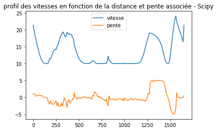

```python
pente = np.array(table['pente'])
pente2 = np.array([pente.tolist()[10*i] for i in range(166)])
import matplotlib.pyplot as plt
plt.figure(1)
X = [10*i for i in range(n2)]
Y = tableau_résultat["vitesse en km/h"]
plt.plot(X, Y, label = 'vitesse')
plt.plot(X, pente2, label = 'pente')
plt.legend()
plt.title('profil des vitesses en fonction de la distance et pente associée - Scipy')
plt.show()
```

##### Algorithme d'Arrow-Hurwitz avec pas de Wolfe

On va maintenant tenter de résoudre le même problème en utilisant l'algorithme d'Arrow-Hurwitz qu'on implémente.

- On implémente tout d'abord les contraintes de notre problème, que l'on va concaténer dans un seul vecteur, de façon à respecter les notations du cours, et on remplace directement la contrainte égalité dans notre fonction de coût (que l'on modifie légèrement) et nos autres contraintes.

```python
# on 'corrige' J
def J_bis(b_1, b_2, h_1, h_2, h_0, L, n, gamma, sigma): #fonctionne (pas d'erreur en tout cas)
    #sigma est un vecteur colonne de taille n
    l = L/n
    sigma[-1] = sigma[0] #apparition de la contrainte égalité dans la fonction  de coût
    U = u(sigma, L, n, h_1, h_2, gamma)
    P = np.zeros(n)
    sum = 0
    for i in range(0,n): #OK car sigma[-1] = sigma[n-1]
        P[i] = b_1*U[i]*l*sigma[i] + b_2*(U[i])**2
        sum+= P[i]/sigma[i]
    return (-0.5*(1/sigma[0])*P[0] - 0.5*(1/sigma[-1])*P[n-1] + sum)


def grad_J_bis(b_1, b_2, h_1, h_2, L, n, sigma, gamma):
    grad = np.zeros(n)
    sigma[-1] = sigma[0] #apparition de la contrainte égalité aussi dans le gradient de la fonction de coût
    l = L/n
    U = u(sigma, L, n, h_1, h_2, gamma)
    for i in range(1, n-1):
        grad += gradP_i(i, sigma, L, n, h_1, h_2, b_1, b_2, gamma)/sigma[i]
        grad += P_i(i, sigma, L, n, h_1, h_2, b_2, gamma)*np.array([0 for _ in range(i)] + [-1/sigma[i]**2] + [0 for _ in range(i+1, n)])
    grad += 0.5*gradP_i(0, sigma, L, n, h_1, h_2, b_1, b_2, gamma)/sigma[0]
    grad += 0.5*P_i(0, sigma, L, n, h_1, h_2, b_2, gamma)*np.array([-1/sigma[0]**2]+[0 for _ in range(n-1)])
    grad += 0.5*gradP_i(n-1, sigma, L, n, h_1, h_2, b_1, b_2, gamma)/sigma[-1]
    grad += 0.5*P_i(n-1, sigma, L, n, h_1, h_2, b_2, gamma)*np.array([0 for _ in range(n-1)] + [-1/sigma[-1]**2])
    return(grad)

#définissons les contraintes et leur gradient


def contrainte(sigma, L, n, h_1, h_2, gamma):
    sigma[-1] = sigma[0] #on remplace tout de suite la contrainte égalité v0 =v(n-1)
    l = L/n
    Liste_contraintes = []
    U = u(sigma, L, n, h_1, h_2, gamma)
    for i in range(n):
        Liste_contraintes.append((U-1)[i]) #contrainte u_i <= 1
    for i in range(n):
        Liste_contraintes.append(-U[i]) #contrainte u_i >= 0
    for i in range(0,n):
        Liste_contraintes.append(v_min - l*sigma[i]) #contrainte v_i >= v_min
    for i in range(0,n):
        Liste_contraintes.append(l*sigma[i] - v_max) #contrainte v_i <= v_max
    return(np.array(Liste_contraintes))

def grad_contrainte(sigma, L, n, h_1, h_2, gamma):
    sigma[-1] = sigma[0]
    l = L/n
    Liste_grad = []
    grad_u = L_grad_u(sigma, L, n, h_1, h_2, gamma)
    for i in range(n):
        Liste_grad.append(grad_u[i]) #contrainte u_i <= 1
    for i in range(n):
        Liste_grad.append(-grad_u[i]) #contrainte u_i >= 0
    I = np.eye(n)
    for i in range(n):
        Liste_grad.append(-l*I[:,i]) #contrainte v_i >= v_min
    for i in range(n):
        Liste_grad.append(l*I[:,i]) #contrainte v_i <= v_max
    return(np.array(Liste_grad))
```

```python
def wolfe_step(fun, grad_fun, xk, pk, c1 = 0.25, c2 = 0.75, M = 1000):
    compteur = 0
    li = 1.0
    lmoins = 0
    lplus = np.inf
    while fun(xk + li*pk)>fun(xk) + c1*li*np.dot(np.transpose(grad_fun(xk)), pk) and np.dot(np.transpose(grad_fun(xk + li*pk)), pk)>c2*np.dot(np.transpose(grad_fun(xk)),pk) and compteur<M:
        if fun(xk + li*pk)>fun(xk) + c1*li*np.dot(np.transpose(grad_fun(xk)), pk):
            lplus = li
            li = 0.5*(lplus+lmoins)
        else:
            lmoins = li
            if lplus == np.inf :
                li = 2*li
            else:
                li = 0.5*(lplus+lmoins)
        compteur+=1
    return li


def arrow_hurwicz(fun, grad_fun, c, grad_c, x0, rho, lambda0, max_iter = 1000, epsilon_grad_L = 10000):
    n = len(x0)
    compteur = 0
    xk = x0
    lambdak = lambda0
    grad_L = grad_fun(xk) + np.matmul( np.transpose(lambdak), grad_c(xk))
    while compteur<max_iter and np.linalg.norm(grad_L)>epsilon_grad_L:
        pk = - grad_L/np.linalg.norm(grad_L)
        lk = wolfe_step(lambda x : fun(x) + np.matmul(lambdak, c(x)), lambda x: grad_fun(x)+ np.matmul(lambdak,grad_c(x)), xk, pk) # car on veut minimiser le LAGRANGIEN !
        xk = xk + lk*pk
        for i in range(0, 4*n):
            lambdak [i] = max(0, lambdak[i] + (1/rho)*c(xk)[i])
        grad_L = grad_fun(xk) + np.matmul(lambdak,grad_c(xk))
        compteur += 1
        print(f"itération n° {compteur}")
        print("Temps d execution : %s secondes ---" % (time.time() - start_time))
        print(f"norme du gradient du Lagrangien : {np.linalg.norm(grad_L)}")
        print(f"norme du gradient de J : {np.linalg.norm(grad_fun(xk))}")
    return(xk, compteur)
```

On applique cet algorithme à notre fonction $J$ avec les ordres de grandeur définis précédemment

```python
start_time = time.time()

res3 = arrow_hurwicz(lambda sigma : J_bis(b_1, b_2, h_1, h_2, h_0, L, n2, gamma2, sigma),
              lambda sigma: grad_J_bis(b_1, b_2, h_1, h_2, L, n2, sigma, gamma2),
              lambda sigma: contrainte(sigma, L, n2, h_1, h_2, gamma2),
              lambda sigma: grad_contrainte(sigma, L, n2, h_1, h_2, gamma2),
              np.array([0.4 for i in range(n2)]), 0.1, np.array([1.0 for _ in range(4*n2)]), 100)
res3
```

```
itération n° 1
Temps d execution : 4.435577869415283 secondes ---
norme du gradient du Lagrangien : 33330.30235212383
norme du gradient de J : 33325.09912703779
itération n° 2
Temps d execution : 9.909816980361938 secondes ---
norme du gradient du Lagrangien : 26641.09539917413
norme du gradient de J : 26635.60588093133
itération n° 3
Temps d execution : 11.957572937011719 secondes ---
norme du gradient du Lagrangien : 155673.71176060237
norme du gradient de J : 155125.24853488183
itération n° 4
Temps d execution : 15.642538070678711 secondes ---
norme du gradient du Lagrangien : 92589.64722415264
norme du gradient de J : 91446.68357015963
itération n° 5
Temps d execution : 19.805514097213745 secondes ---
norme du gradient du Lagrangien : 81824.08635499762
norme du gradient de J : 80202.11696095884
itération n° 6
Temps d execution : 24.539088010787964 secondes ---
norme du gradient du Lagrangien : 76272.53288775725
norme du gradient de J : 74415.84520638932
itération n° 7
Temps d execution : 29.54934573173523 secondes ---
norme du gradient du Lagrangien : 79019.11612713222
norme du gradient de J : 76796.54944165357
itération n° 8
Temps d execution : 35.436320066452026 secondes ---
norme du gradient du Lagrangien : 71416.92425743335
norme du gradient de J : 68643.57870092626
itération n° 9
Temps d execution : 37.80585503578186 secondes ---
norme du gradient du Lagrangien : 96164.95235870466
norme du gradient de J : 93716.20158791199
itération n° 10
Temps d execution : 44.85243773460388 secondes ---
norme du gradient du Lagrangien : 78646.94054280368
norme du gradient de J : 75214.40144087965
```

[output cut: 345 more lines]

```
Temps d execution : 486.4839789867401 secondes ---
norme du gradient du Lagrangien : 247518.29058177862
norme du gradient de J : 161584.39959839213
itération n° 98
Temps d execution : 491.8278748989105 secondes ---
norme du gradient du Lagrangien : 210425.65574383872
norme du gradient de J : 123235.69965837122
itération n° 99
Temps d execution : 495.6448049545288 secondes ---
norme du gradient du Lagrangien : 217526.44031006398
norme du gradient de J : 164122.9877269542
itération n° 100
Temps d execution : 500.32084798812866 secondes ---
norme du gradient du Lagrangien : 218227.97873537117
norme du gradient de J : 127316.90033516975
```

```
(array([2.07645543, 1.94073224, 1.80067858, 1.66029179, 1.51899362,
        1.37558163, 1.23452528, 1.09580646, 0.96513077, 0.84182171,
        0.72791817, 0.62882301, 0.54269803, 0.46877422, 0.4067304 ,
        0.356952  , 0.32463678, 0.3108869 , 0.30642404, 0.2926713 ,
        0.28853456, 0.28799628, 0.28783223, 0.28381375, 0.27963154,
        0.26896228, 0.27447786, 0.26642967, 0.27175281, 0.27661164,
        0.28020978, 0.2753421 , 0.28695159, 0.28404178, 0.26732682,
        0.25704995, 0.25913249, 0.28082093, 0.27552164, 0.26794563,
        0.27647192, 0.27909459, 0.28301965, 0.28219251, 0.28528856,
        0.26754944, 0.2649431 , 0.26270346, 0.26628971, 0.26460177,
        0.26393007, 0.2666339 , 0.2663706 , 0.26777146, 0.26765717,
        0.26823321, 0.26457171, 0.26475266, 0.26458998, 0.2654199 ,
        0.26531361, 0.26553666, 0.26631763, 0.27304143, 0.2839092 ,
        0.28486667, 0.29032345, 0.28242658, 0.27590996, 0.27274194,
        0.27329786, 0.27775169, 0.27765071, 0.27967104, 0.28052455,
        0.28111013, 0.28148243, 0.27951439, 0.27971253, 0.27950588,
        0.27116613, 0.27790873, 0.29460411, 0.27773245, 0.27464147,
        0.27304423, 0.27223291, 0.27297644, 0.2716494 , 0.27114093,
        0.27493454, 0.27457965, 0.27467193, 0.27506656, 0.27445021,
        0.27477833, 0.2748025 , 0.27562965, 0.27381041, 0.27967068,
        0.2746278 , 0.27353953, 0.27381423, 0.27583971, 0.27575041,
        0.27747071, 0.27562553, 0.27433158, 0.2717844 , 0.27442956,
        0.27374634, 0.27201762, 0.27123486, 0.27026822, 0.2705114 ,
        0.27276549, 0.27594799, 0.28377073, 0.29427999, 0.31194128,
        0.33306403, 0.35538871, 0.38440117, 0.41686436, 0.4469405 ,
        0.47409192, 0.4957005 , 0.5237913 , 0.52840811, 0.5250601 ,
        0.52134161, 0.51714584, 0.51521658, 0.51034803, 0.50367804,
        0.49668218, 0.48833565, 0.47829377, 0.46611152, 0.45119975,
        0.43275236, 0.41070959, 0.38274749, 0.35225163, 0.32498591,
        0.3065056 , 0.3014075 , 0.30435309, 0.31797797, 0.34421008,
        0.39519305, 0.46162389, 0.53819344, 0.62451155, 0.71690525,
        0.81061345, 0.91397306, 0.98231797, 1.09992496, 1.17549254,
        1.32955754, 1.41873219, 1.55703177, 1.69998461, 1.80281166,
        2.07645543]), 100)
```

```python
sigma_optim_wolfe = res3[0]
```

```python
tableau_résultat_2 = pd.DataFrame(sigma_optim_wolfe, index = [f"{10*i} m" for i in range(n2)], columns = ["sigma"])
tableau_résultat_2["vitesse en m/s"]=(L/n2)*tableau_résultat_2["sigma"]
tableau_résultat_2["vitesse en km/h"] = 3.6*tableau_résultat_2["vitesse en m/s"]
tableau_résultat_2
```

|  | sigma | vitesse en m/s | vitesse en km/h |
| --- | --- | --- | --- |
| 0 m | 2.076455 | 20.752046 | 74.707364 |
| 10 m | 1.940732 | 19.395631 | 69.824272 |
| 20 m | 1.800679 | 17.995938 | 64.785378 |
| 30 m | 1.660292 | 16.592916 | 59.734498 |
| 40 m | 1.518994 | 15.180786 | 54.650828 |
| 50 m | 1.375582 | 13.747530 | 49.491107 |
| 60 m | 1.234525 | 12.337816 | 44.416137 |
| 70 m | 1.095806 | 10.951463 | 39.425268 |
| 80 m | 0.965131 | 9.645494 | 34.723777 |
| 90 m | 0.841822 | 8.413146 | 30.287325 |
| 100 m | 0.727918 | 7.274797 | 26.189268 |
| 110 m | 0.628823 | 6.284442 | 22.623991 |
| 120 m | 0.542698 | 5.423711 | 19.525360 |
| 130 m | 0.468774 | 4.684918 | 16.865706 |
| 140 m | 0.406730 | 4.064854 | 14.633474 |
| 150 m | 0.356952 | 3.567370 | 12.842531 |
| 160 m | 0.324637 | 3.244412 | 11.679884 |
| 170 m | 0.310887 | 3.106996 | 11.185186 |
| 180 m | 0.306424 | 3.062395 | 11.024620 |
| 190 m | 0.292671 | 2.924950 | 10.529820 |
| 200 m | 0.288535 | 2.883607 | 10.380987 |
| 210 m | 0.287996 | 2.878228 | 10.361620 |
| 220 m | 0.287832 | 2.876588 | 10.355718 |
| 230 m | 0.283814 | 2.836428 | 10.211140 |
| 240 m | 0.279632 | 2.794631 | 10.060671 |
| 250 m | 0.268962 | 2.688003 | 9.676809 |
| 260 m | 0.274478 | 2.743125 | 9.875250 |
| 270 m | 0.266430 | 2.662692 | 9.585690 |
| 280 m | 0.271753 | 2.715891 | 9.777208 |
| 290 m | 0.276612 | 2.764450 | 9.952020 |
| ... | ... | ... | ... |
| 1360 m | 0.488336 | 4.880415 | 17.569493 |
| 1370 m | 0.478294 | 4.780056 | 17.208203 |
| 1380 m | 0.466112 | 4.658307 | 16.769906 |
| 1390 m | 0.451200 | 4.509279 | 16.233406 |
| 1400 m | 0.432752 | 4.324917 | 15.569700 |
| 1410 m | 0.410710 | 4.104622 | 14.776638 |
| 1420 m | 0.382747 | 3.825169 | 13.770609 |
| 1430 m | 0.352252 | 3.520394 | 12.673420 |
| 1440 m | 0.324986 | 3.247901 | 11.692445 |
| 1450 m | 0.306506 | 3.063210 | 11.027555 |
| 1460 m | 0.301407 | 3.012259 | 10.844133 |
| 1470 m | 0.304353 | 3.041697 | 10.950111 |
| 1480 m | 0.317978 | 3.177864 | 11.440311 |
| 1490 m | 0.344210 | 3.440027 | 12.384098 |
| 1500 m | 0.395193 | 3.949550 | 14.218379 |
| 1510 m | 0.461624 | 4.613458 | 16.608449 |
| 1520 m | 0.538193 | 5.378692 | 19.363292 |
| 1530 m | 0.624512 | 6.241353 | 22.468872 |
| 1540 m | 0.716905 | 7.164734 | 25.793042 |
| 1550 m | 0.810613 | 8.101251 | 29.164505 |
| 1560 m | 0.913973 | 9.134225 | 32.883209 |
| 1570 m | 0.982318 | 9.817262 | 35.342144 |
| 1580 m | 1.099925 | 10.992624 | 39.573445 |
| 1590 m | 1.175493 | 11.747844 | 42.292239 |
| 1600 m | 1.329558 | 13.287566 | 47.835238 |
| 1610 m | 1.418732 | 14.178775 | 51.043591 |
| 1620 m | 1.557032 | 15.560938 | 56.019377 |
| 1630 m | 1.699985 | 16.989605 | 61.162579 |
| 1640 m | 1.802812 | 18.017256 | 64.862123 |
| 1650 m | 2.076455 | 20.752046 | 74.707364 |

166 rows × 3 columns

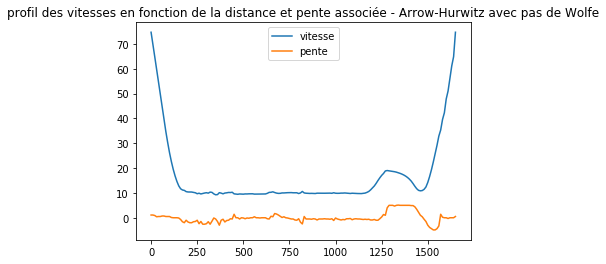

```python
pente = np.array(table['pente'])
pente2 = np.array([pente.tolist()[10*i] for i in range(166)])
import matplotlib.pyplot as plt
plt.figure(1)
X = [10*i for i in range(n2)]
Y = tableau_résultat_2["vitesse en km/h"]
plt.plot(X, Y, label = 'vitesse')
plt.plot(X, pente2, label = 'pente')
plt.legend()
plt.title('profil des vitesses en fonction de la distance et pente associée - Arrow-Hurwitz avec pas de Wolfe')
plt.show()
```

```python
E_0 = J(b_1, b_2, h_1, h_2, h_0, L, n2, gamma2, sigma_optim_wolfe)
print(f"E_o a pour valeur minimale : {E_0} J")
```

```
E_o a pour valeur minimale : 276093.1676273991 J
```

```python
E_tot = 79.2 * 10**6
print(f"N vaut {int(E_tot/E_0)}")
```

```
N vaut 286
```

On remarque que le profil des vitesses est assez éloigné de celui qu'on trouve avec scipy. Le nombre de tours trouvé (286) est lui aussi éloigné du résultat donné par scipy (394). Cela est dû au fait que l'algorithme ne converge pas encore car on a un trop petit nombre d'itérations.  
Cependant, comme le programme est plutôt lent (plus de 5s par boucle), on ne peut pas réaliser le nombre d'itérations qui serait nécessaire à moins de faire tourner l'algorithme pendant plusieurs jours. (À titre d'exemple, nous avons réalisé un essai à 1000 itérations seulement, qui a nécessité plus de 3 heures de calcul)

On va donc les calculs en utilisant un pas fixe au lieu d'un pas de wolfe. Cela nous permettra de réaliser plus d'itérations puisque chaque boucle sera plus rapide.

##### Algorithme d'Arrow-Hurwitz à pas fixe

```python
def arrow_hurwitz_fixed_step(fun, grad_fun, c, grad_c, x0, l, rho, lambda0, max_iter = 100, epsilon_grad_L = 0.02):
    n = len(x0)
    compteur = 0
    xk = x0
    lambdak = lambda0
    grad_L = grad_fun(xk) + np.matmul(np.transpose(lambdak), grad_c(xk))
    while compteur<max_iter and np.linalg.norm(grad_L)>epsilon_grad_L:
        grad_L = grad_fun(xk) + np.matmul(lambdak,grad_c(xk))
        pk = - grad_L/np.linalg.norm(grad_L)
        xk = xk + l*pk
        for i in range(0, 4*n):
            lambdak [i] = max(0, lambdak[i] + (1/rho)*c(xk)[i])
        compteur += 1
        print(f"itération n° {compteur}")
        print("Temps d execution : %s secondes ---" % (time.time() - start_time))
        print(f"norme du gradient du Lagrangien : {np.linalg.norm(grad_L)}")
        print(f"norme du gradient de J : {np.linalg.norm(grad_fun(xk))}")
    return(xk, compteur)
```

**Attention, ne pas ré-exécuter la cellule suivante (le temps de calcul est de près de 3h)**

```python
start_time = time.time()

res4 = arrow_hurwitz_fixed_step(lambda sigma : J_bis(b_1, b_2, h_1, h_2, h_0, L, n2, gamma2, sigma),
              lambda sigma: grad_J_bis(b_1, b_2, h_1, h_2, L, n2, sigma, gamma2),
              lambda sigma: contrainte(sigma, L, n2, h_1, h_2, gamma2),
              lambda sigma: grad_contrainte(sigma, L, n2, h_1, h_2, gamma2),
              np.array([0.5 for i in range(n2)]), 0.01, 0.1, np.array([1.0 for _ in range(4*n2)]),10000)

res4
```

```
itération n° 1
Temps d execution : 1.2141330242156982 secondes ---
norme du gradient du Lagrangien : 44078.41512660873
norme du gradient de J : 41120.045615847965
itération n° 2
Temps d execution : 2.3782970905303955 secondes ---
norme du gradient du Lagrangien : 41131.54465426505
norme du gradient de J : 38516.47368160544
itération n° 3
Temps d execution : 3.530372142791748 secondes ---
norme du gradient du Lagrangien : 38534.49646852151
norme du gradient de J : 36275.32162927446
itération n° 4
Temps d execution : 4.723929166793823 secondes ---
norme du gradient du Lagrangien : 36298.89624628603
norme du gradient de J : 34395.132492000055
itération n° 5
Temps d execution : 5.898630142211914 secondes ---
norme du gradient du Lagrangien : 34423.60644839409
norme du gradient de J : 32864.27406022502
itération n° 6
Temps d execution : 7.124238014221191 secondes ---
norme du gradient du Lagrangien : 32896.94982824291
norme du gradient de J : 31660.968928326736
itération n° 7
Temps d execution : 8.349210023880005 secondes ---
norme du gradient du Lagrangien : 31697.078908738873
norme du gradient de J : 30754.82450792253
itération n° 8
Temps d execution : 9.465697050094604 secondes ---
norme du gradient du Lagrangien : 30793.637378106436
norme du gradient de J : 30109.566717132937
itération n° 9
Temps d execution : 10.600304126739502 secondes ---
norme du gradient du Lagrangien : 30150.51577929897
norme du gradient de J : 29686.350873393316
itération n° 10
Temps d execution : 11.751943826675415 secondes ---
norme du gradient du Lagrangien : 29728.48858681803
norme du gradient de J : 29446.91179833074
```

[output cut: 39945 more lines]

```
Temps d execution : 13494.519416093826 secondes ---
norme du gradient du Lagrangien : 44943.89903232101
norme du gradient de J : 46372.83774551905
itération n° 9998
Temps d execution : 13495.980013132095 secondes ---
norme du gradient du Lagrangien : 44947.674787123906
norme du gradient de J : 46376.21639905963
itération n° 9999
Temps d execution : 13497.298381090164 secondes ---
norme du gradient du Lagrangien : 44951.44922624387
norme du gradient de J : 46379.594308312866
itération n° 10000
Temps d execution : 13498.665179252625 secondes ---
norme du gradient du Lagrangien : 44955.22234829132
norme du gradient de J : 46382.971471716366
```

```
(array([0.7662002 , 0.72986511, 0.69522637, 0.66714987, 0.63675796,
        0.60544248, 0.56938778, 0.53168061, 0.49638344, 0.45943651,
        0.42055504, 0.39064417, 0.36283281, 0.33449074, 0.30552555,
        0.27923988, 0.277151  , 0.29260834, 0.31894891, 0.3142555 ,
        0.33065546, 0.35403527, 0.37567585, 0.38620869, 0.39382855,
        0.38872435, 0.41692053, 0.42338387, 0.45292532, 0.48020795,
        0.50191428, 0.50766561, 0.53126489, 0.53251705, 0.50893375,
        0.4928667 , 0.49685918, 0.52813375, 0.52185724, 0.50768992,
        0.51487837, 0.51033145, 0.50369189, 0.48439793, 0.46665983,
        0.41616397, 0.38484795, 0.35683154, 0.33862875, 0.31851328,
        0.30315025, 0.29499257, 0.28677139, 0.28305408, 0.28012637,
        0.28015621, 0.27810615, 0.27795282, 0.27793921, 0.27794255,
        0.27794466, 0.27794521, 0.27794558, 0.28343446, 0.29344778,
        0.29357532, 0.2981829 , 0.28937876, 0.28165456, 0.2779456 ,
        0.27794556, 0.27846775, 0.27794549, 0.27794547, 0.27794546,
        0.27794545, 0.27794545, 0.27794545, 0.27794551, 0.27990584,
        0.2779448 , 0.30022137, 0.33954166, 0.31099521, 0.29732797,
        0.2872484 , 0.28068144, 0.27882448, 0.27794714, 0.2779398 ,
        0.27865742, 0.27793818, 0.27793717, 0.2779363 , 0.27793547,
        0.27793469, 0.27793403, 0.27793364, 0.27793367, 0.28237775,
        0.27793316, 0.27793287, 0.27793348, 0.27793505, 0.27793761,
        0.27866677, 0.27794068, 0.2779412 , 0.27794267, 0.27804881,
        0.27794357, 0.27794288, 0.27794282, 0.27794352, 0.27794446,
        0.27849679, 0.28131005, 0.28880683, 0.29859521, 0.31540674,
        0.33574209, 0.3574381 , 0.38600434, 0.41819921, 0.44816001,
        0.47531121, 0.49700036, 0.52520282, 0.52997562, 0.52680086,
        0.52325183, 0.51920725, 0.51739336, 0.51260131, 0.50596331,
        0.49894429, 0.49050693, 0.48028814, 0.46781451, 0.45245275,
        0.43332769, 0.41027003, 0.38077057, 0.3479218 , 0.31709529,
        0.293488  , 0.28161063, 0.2779801 , 0.27854327, 0.29190916,
        0.34681578, 0.41386711, 0.48087769, 0.54759148, 0.60672461,
        0.65324041, 0.68138991, 0.64714934, 0.62879468, 0.61807798,
        0.61334555, 0.61725296, 0.62467549, 0.63820875, 0.65786683,
        0.7662002 ]), 10000)
```

```python
sigma_optim_fixe = res4[0]
```

```python
tableau_résultat_3 = pd.DataFrame(sigma_optim_fixe, index = [f"{10*i} m" for i in range(n2)], columns = ["sigma"])
tableau_résultat_3["vitesse en m/s"]=(L/n2)*tableau_résultat_3["sigma"]
tableau_résultat_3["vitesse en km/h"] = 3.6*tableau_résultat_3["vitesse en m/s"]
tableau_résultat_3
```

|  | sigma | vitesse en m/s | vitesse en km/h |
| --- | --- | --- | --- |
| 0 m | 0.766200 | 7.657386 | 27.566591 |
| 10 m | 0.729865 | 7.294254 | 26.259315 |
| 20 m | 0.695226 | 6.948076 | 25.013072 |
| 30 m | 0.667150 | 6.667480 | 24.002927 |
| 40 m | 0.636758 | 6.363744 | 22.909478 |
| 50 m | 0.605442 | 6.050778 | 21.782799 |
| 60 m | 0.569388 | 5.690448 | 20.485612 |
| 70 m | 0.531681 | 5.313603 | 19.128972 |
| 80 m | 0.496383 | 4.960844 | 17.859039 |
| 90 m | 0.459437 | 4.591597 | 16.529751 |
| 100 m | 0.420555 | 4.203017 | 15.130861 |
| 110 m | 0.390644 | 3.904088 | 14.054718 |
| 120 m | 0.362833 | 3.626142 | 13.054112 |
| 130 m | 0.334491 | 3.342892 | 12.034413 |
| 140 m | 0.305526 | 3.053415 | 10.992294 |
| 150 m | 0.279240 | 2.790717 | 10.046580 |
| 160 m | 0.277151 | 2.769840 | 9.971426 |
| 170 m | 0.292608 | 2.924321 | 10.527554 |
| 180 m | 0.318949 | 3.187568 | 11.475244 |
| 190 m | 0.314255 | 3.140662 | 11.306383 |
| 200 m | 0.330655 | 3.304563 | 11.896426 |
| 210 m | 0.354035 | 3.538220 | 12.737592 |
| 220 m | 0.375676 | 3.754495 | 13.516183 |
| 230 m | 0.386209 | 3.859760 | 13.895137 |
| 240 m | 0.393829 | 3.935913 | 14.169287 |
| 250 m | 0.388724 | 3.884902 | 13.985646 |
| 260 m | 0.416921 | 4.166694 | 15.000098 |
| 270 m | 0.423384 | 4.231288 | 15.232637 |
| 280 m | 0.452925 | 4.526525 | 16.295489 |
| 290 m | 0.480208 | 4.799187 | 17.277072 |
| ... | ... | ... | ... |
| 1360 m | 0.490507 | 4.902114 | 17.647612 |
| 1370 m | 0.480288 | 4.799988 | 17.279957 |
| 1380 m | 0.467815 | 4.675327 | 16.831177 |
| 1390 m | 0.452453 | 4.521802 | 16.278487 |
| 1400 m | 0.433328 | 4.330667 | 15.590400 |
| 1410 m | 0.410270 | 4.100229 | 14.760824 |
| 1420 m | 0.380771 | 3.805412 | 13.699483 |
| 1430 m | 0.347922 | 3.477122 | 12.517640 |
| 1440 m | 0.317095 | 3.169043 | 11.408554 |
| 1450 m | 0.293488 | 2.933112 | 10.559203 |
| 1460 m | 0.281611 | 2.814410 | 10.131876 |
| 1470 m | 0.277980 | 2.778126 | 10.001255 |
| 1480 m | 0.278543 | 2.783755 | 10.021517 |
| 1490 m | 0.291909 | 2.917333 | 10.502399 |
| 1500 m | 0.346816 | 3.466069 | 12.477847 |
| 1510 m | 0.413867 | 4.136178 | 14.890241 |
| 1520 m | 0.480878 | 4.805880 | 17.301168 |
| 1530 m | 0.547591 | 5.472616 | 19.701418 |
| 1540 m | 0.606725 | 6.063591 | 21.828928 |
| 1550 m | 0.653240 | 6.528469 | 23.502488 |
| 1560 m | 0.681390 | 6.809794 | 24.515260 |
| 1570 m | 0.647149 | 6.467595 | 23.283342 |
| 1580 m | 0.628795 | 6.284159 | 22.622972 |
| 1590 m | 0.618078 | 6.177056 | 22.237403 |
| 1600 m | 0.613346 | 6.129761 | 22.067138 |
| 1610 m | 0.617253 | 6.168811 | 22.207721 |
| 1620 m | 0.624675 | 6.242992 | 22.474770 |
| 1630 m | 0.638209 | 6.378243 | 22.961674 |
| 1640 m | 0.657867 | 6.574705 | 23.668939 |
| 1650 m | 0.766200 | 7.657386 | 27.566591 |

166 rows × 3 columns

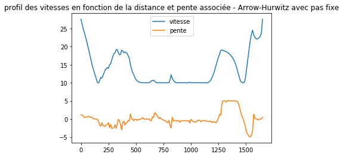

```python
pente = np.array(table['pente'])
pente2 = np.array([pente.tolist()[10*i] for i in range(166)])
import matplotlib.pyplot as plt
plt.figure(1)
X = [10*i for i in range(n2)]
Y = tableau_résultat_3["vitesse en km/h"]
plt.plot(X, Y, label = 'vitesse')
plt.plot(X, pente2, label = 'pente')
plt.legend()
plt.title('profil des vitesses en fonction de la distance et pente associée - Arrow-Hurwitz avec pas fixe')
plt.show()
```

```python
E_0 = J(b_1, b_2, h_1, h_2, h_0, L, n2, gamma2, sigma_optim_fixe)
print(f"E_o a pour valeur minimale : {E_0} J")
```

```
E_o a pour valeur minimale : 203130.77375050893 J
```

```python
E_tot = 79.2 * 10**6
print(f"N vaut {int(E_tot/E_0)}")
```

```
N vaut 389
```

Ici, on trouve un nombre de tours maximum assez proche de celui qu'on a trouvé avec scipy ($N=389$ ici contre $N=394$ avec scipy). On n'a pas égalité car on a seulement une solution approchée du problème d'optimisation, mais le résultat est tout de même plus satisfaisant qu'en utilisant le pas de Wolfe.

Cela est dû au fait qu'on a pu réalisé 10 000 itérations, car cet algorithme est plus rapide (1s par boucle environ). Le temps d'exécution de l'algorithme est cependant très long (plus de 3h).

## III/ Étude avancée

On souhaite prendre en compte les non-linéarités du moteur et en particulier les saturations de la tension pour les faibles et basses valeurs de couple moteur.

### Question 1

Modifier le problème donné en annexe en conséquence. Quelles sont les conséquences de ces saturations sur le problème de minimisation ?

### Question 2

Proposer un algorithme permettant de traiter ce nouveau problème et de l'implémenter.